# LCL Fiber-seq: top 10 heterozygous AS-FIRE regions

### rank03_rs4061832_chr3_98334086_98334294

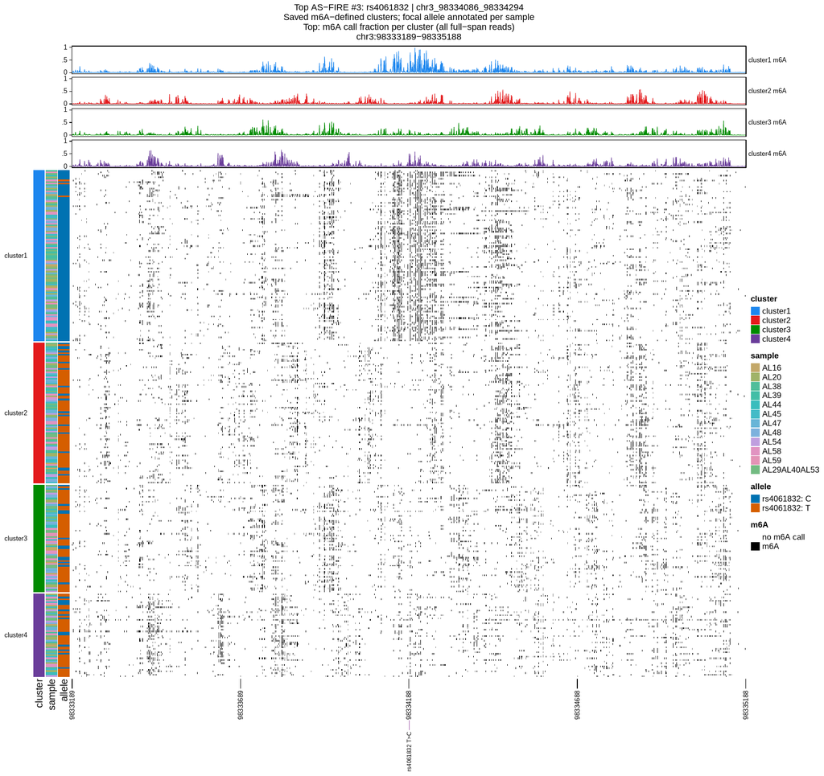

rank03_rs4061832_chr3_98334086_98334294 — m6A and footprint heatmaps

Download original PDF: heatmap_m6a_footprints

### rank04_rs170738_chr5_55421001_55421578

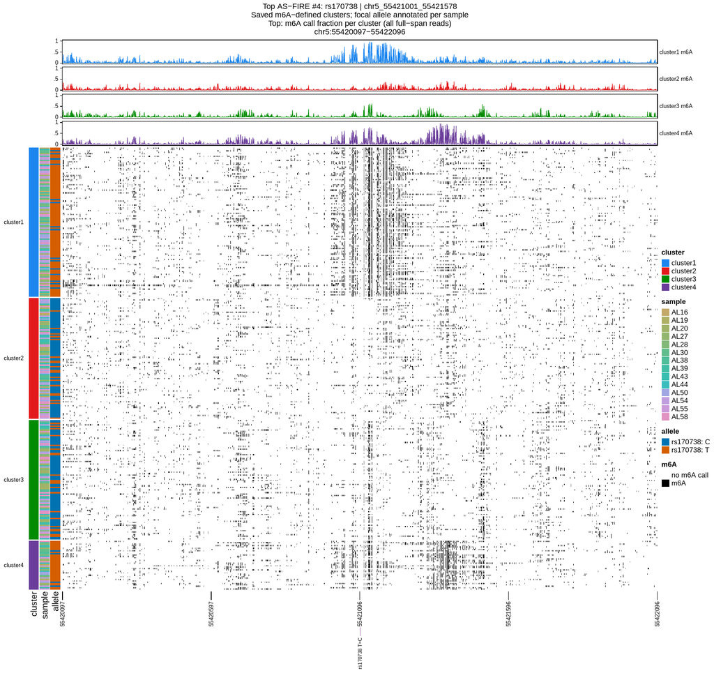

rank04_rs170738_chr5_55421001_55421578 — m6A and footprint heatmaps

Download original PDF: heatmap_m6a_footprints

### rank05_rs1457288_chr8_109521517_109521780

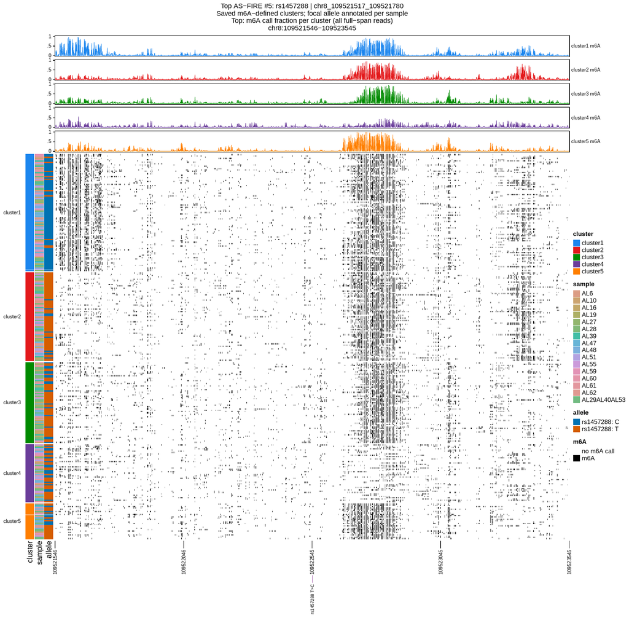

rank05_rs1457288_chr8_109521517_109521780 — m6A and footprint heatmaps

Download original PDF: heatmap_m6a_footprints

### rank06_rs10826861_chr10_30751957_30752154

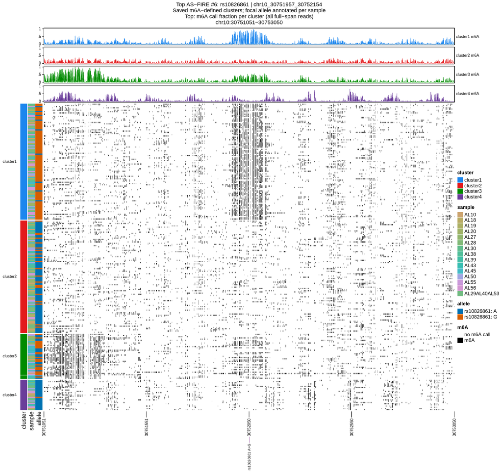

rank06_rs10826861_chr10_30751957_30752154 — m6A and footprint heatmaps

Download original PDF: heatmap_m6a_footprints

### rank07_rs1999686_chr9_31146879_31147088

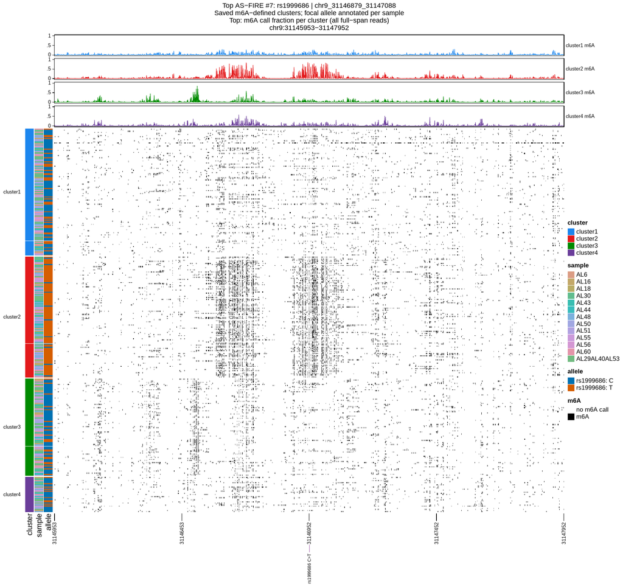

rank07_rs1999686_chr9_31146879_31147088 — m6A and footprint heatmaps

Download original PDF: heatmap_m6a_footprints

### rank08_rs12666349_chr7_31688407_31688773

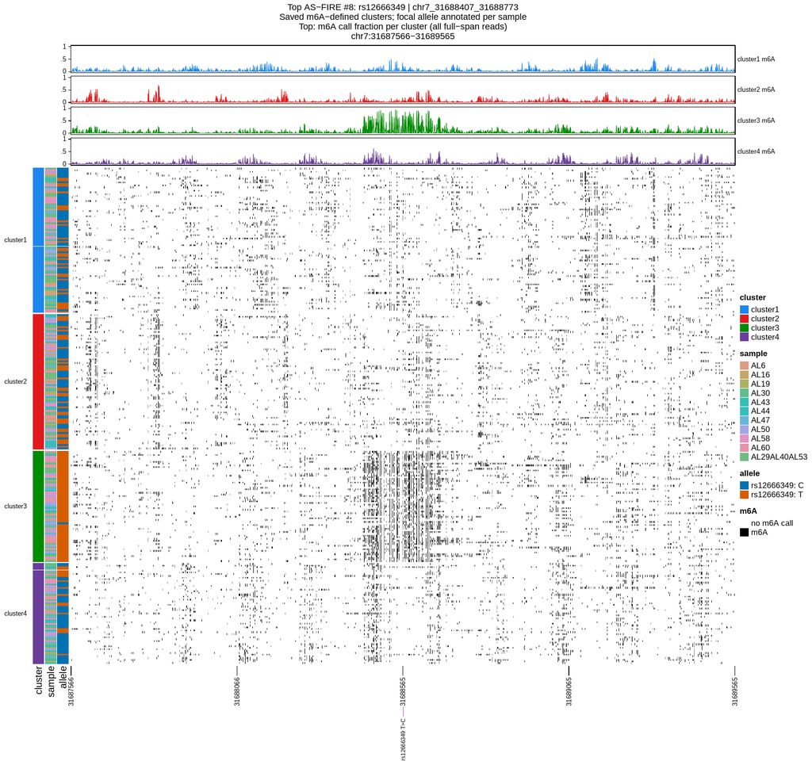

rank08_rs12666349_chr7_31688407_31688773 — m6A and footprint heatmaps

Download original PDF: heatmap_m6a_footprints

### rank09_rs17306827_chr2_173899075_173899320

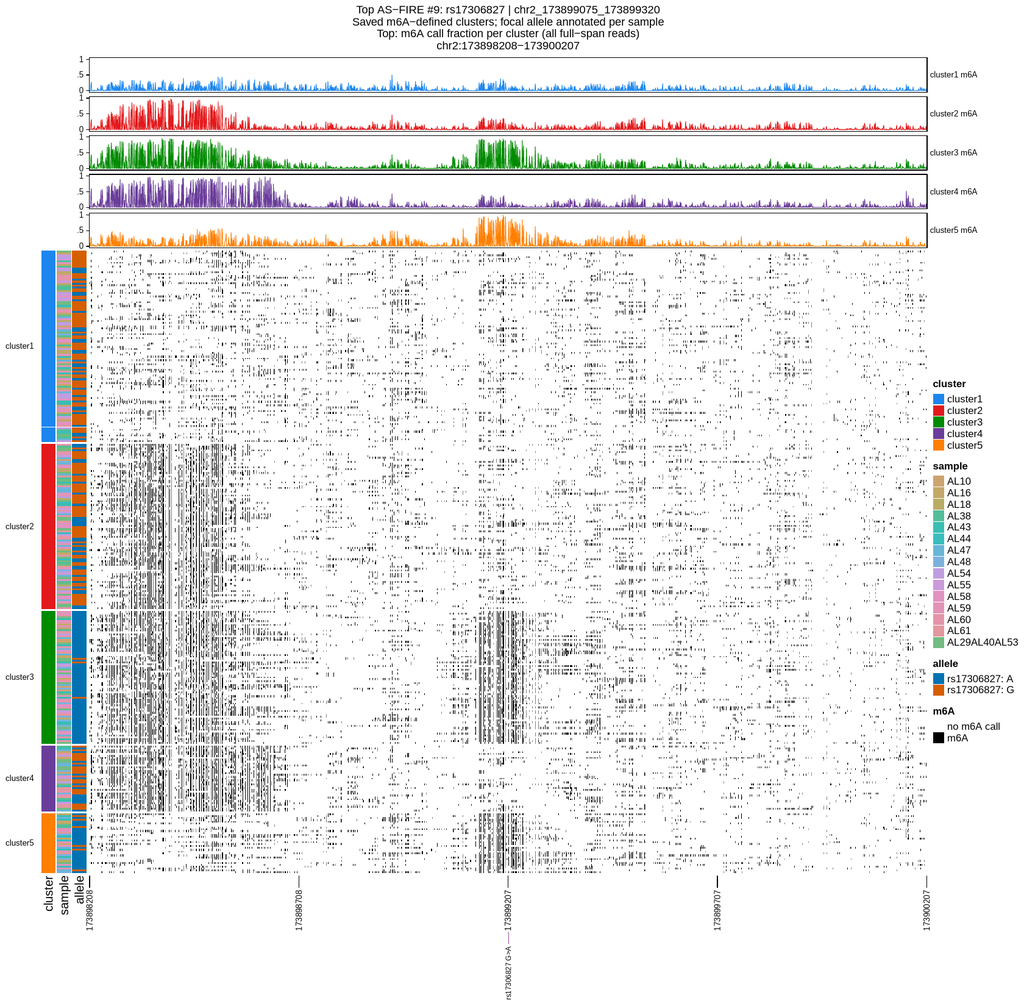

rank09_rs17306827_chr2_173899075_173899320 — m6A and footprint heatmaps

Download original PDF: heatmap_m6a_footprints

### rank10_rs2210798_chr6_8481830_8482016

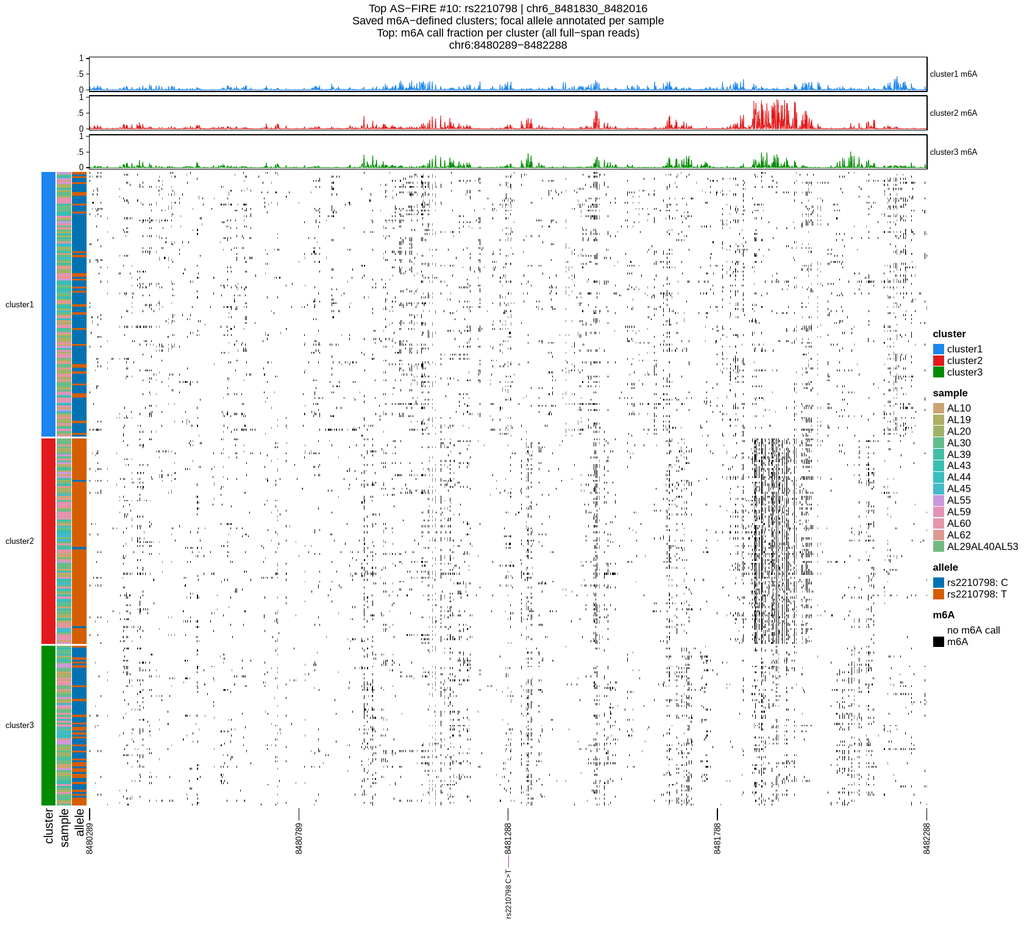

rank10_rs2210798_chr6_8481830_8482016 — m6A and footprint heatmaps

Download original PDF: heatmap_m6a_footprints

# KNN graph

- how similar individual reads are to each other based on their m6A footprint patterns
  - each dot is one read, an edge connects two reads if either selects the other as one of its 10 nearest neighbors.
  - a read can have more than 10 edges if it is selected as a neighbor by multiple other reads

```r
for (rid in names(result_paths)) {
  plot_dir <- lcl_output_path(file.path(dirname(dirname(result_paths[[rid]])), "plots"))
  graph_pdf <- file.path(plot_dir, "knn_graph.pdf")
  if (!file.exists(graph_pdf)) {
    result <- readRDS(result_paths[[rid]])
    dir.create(plot_dir, recursive = TRUE, showWarnings = FALSE)
    ggplot2::ggsave(graph_pdf, plot_knn_graph(result), width = 12, height = 9, bg = "white")
  }
}
figure_gallery("knn_graph", "Manhattan KNN graphs colored by Leiden cluster")
```

## Manhattan KNN graphs colored by Leiden cluster

### rank01_rs12470189_chr2_119290945_119291178

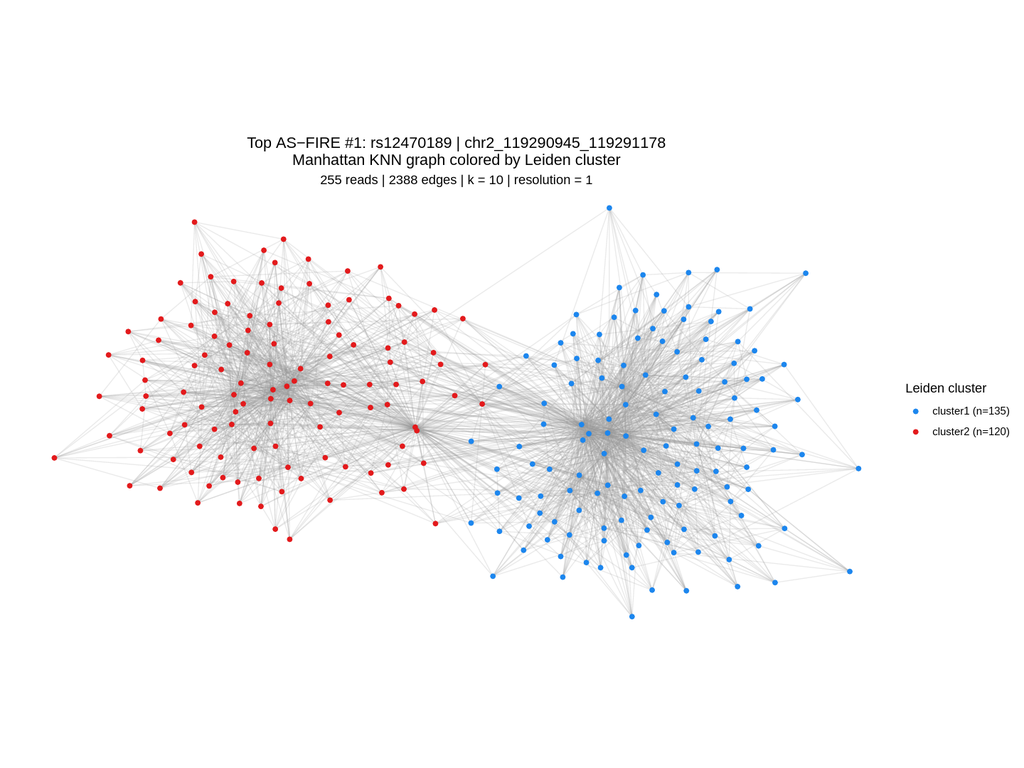

rank01_rs12470189_chr2_119290945_119291178 — Manhattan KNN graphs colored by Leiden cluster

Download original PDF: knn_graph

### rank02_rs2236610_chr21_34688259_34688428

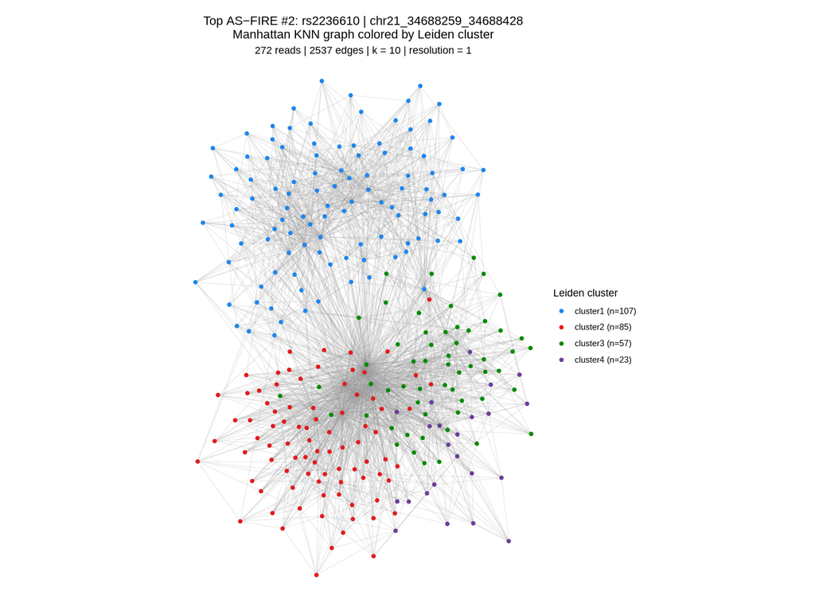

rank02_rs2236610_chr21_34688259_34688428 — Manhattan KNN graphs colored by Leiden cluster

Download original PDF: knn_graph

### rank03_rs4061832_chr3_98334086_98334294

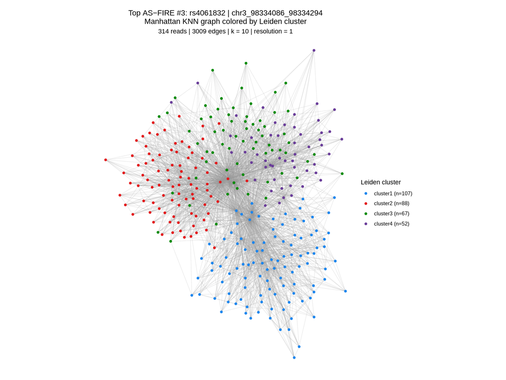

rank03_rs4061832_chr3_98334086_98334294 — Manhattan KNN graphs colored by Leiden cluster

Download original PDF: knn_graph

### rank04_rs170738_chr5_55421001_55421578

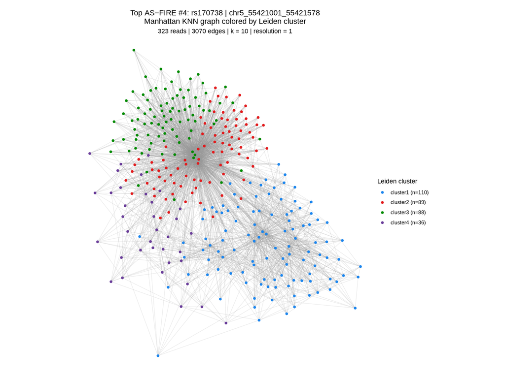

rank04_rs170738_chr5_55421001_55421578 — Manhattan KNN graphs colored by Leiden cluster

Download original PDF: knn_graph

### rank05_rs1457288_chr8_109521517_109521780

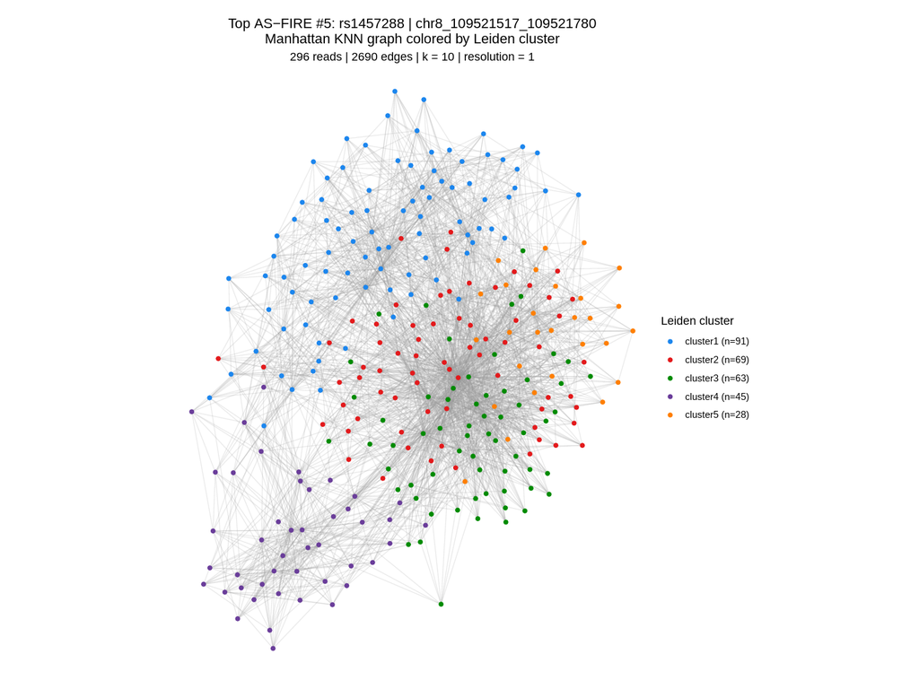

rank05_rs1457288_chr8_109521517_109521780 — Manhattan KNN graphs colored by Leiden cluster

Download original PDF: knn_graph

### rank06_rs10826861_chr10_30751957_30752154

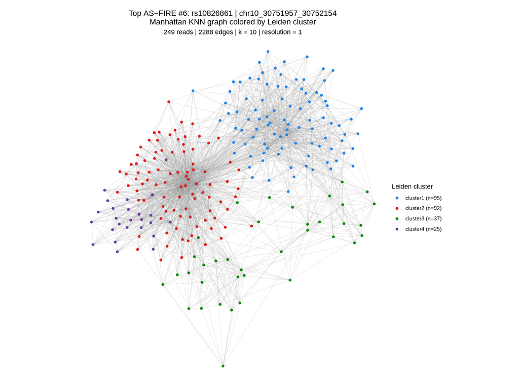

rank06_rs10826861_chr10_30751957_30752154 — Manhattan KNN graphs colored by Leiden cluster

Download original PDF: knn_graph

### rank07_rs1999686_chr9_31146879_31147088

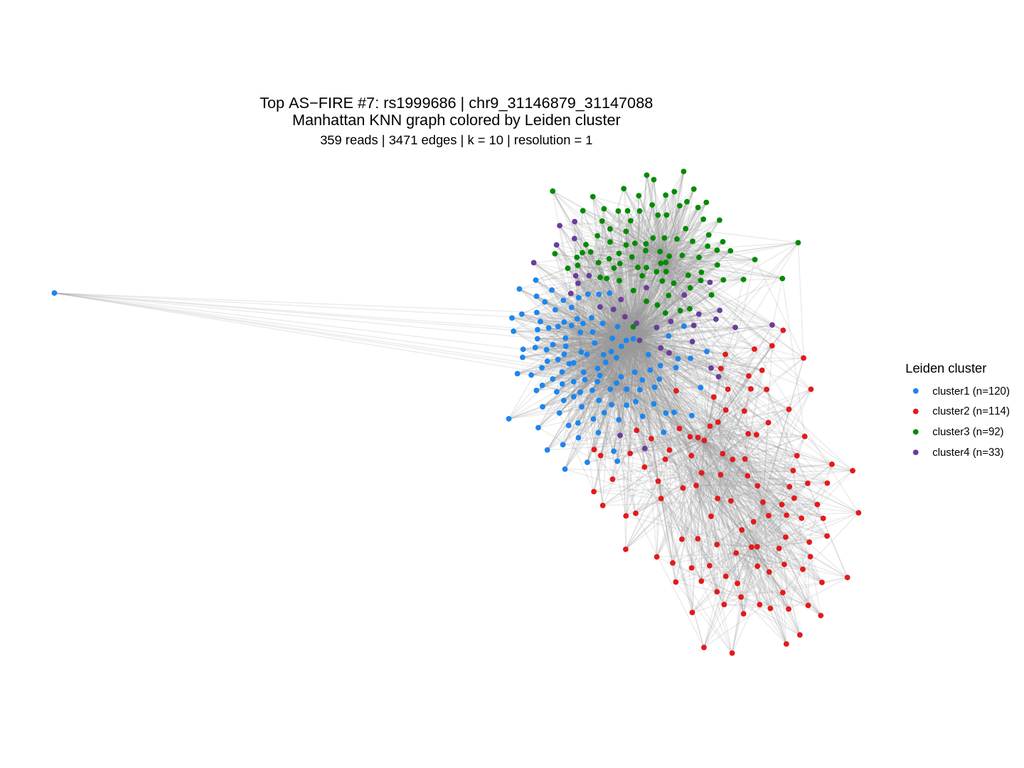

rank07_rs1999686_chr9_31146879_31147088 — Manhattan KNN graphs colored by Leiden cluster

Download original PDF: knn_graph

### rank08_rs12666349_chr7_31688407_31688773

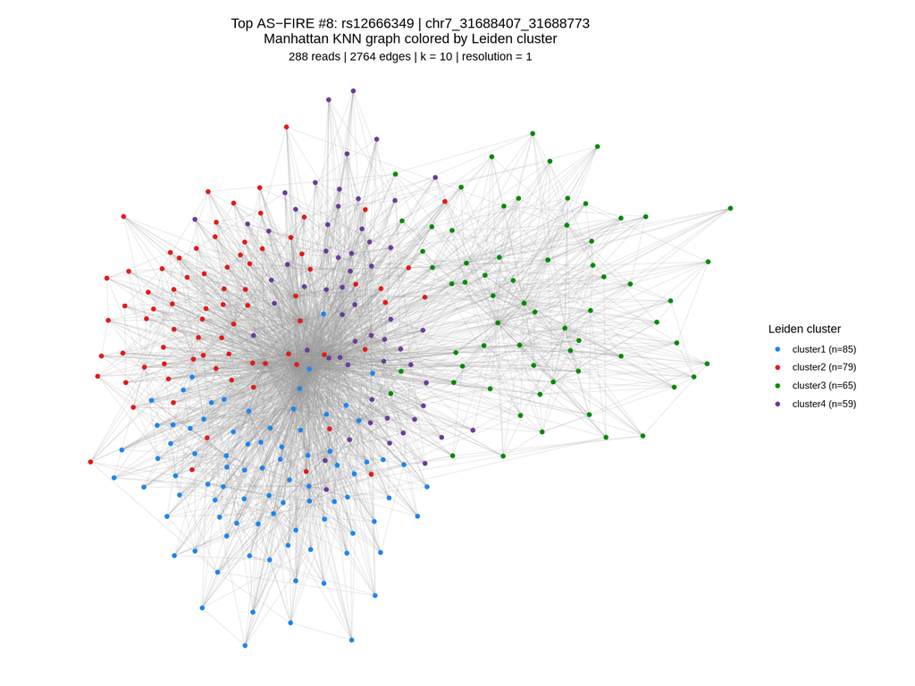

rank08_rs12666349_chr7_31688407_31688773 — Manhattan KNN graphs colored by Leiden cluster

Download original PDF: knn_graph

### rank09_rs17306827_chr2_173899075_173899320

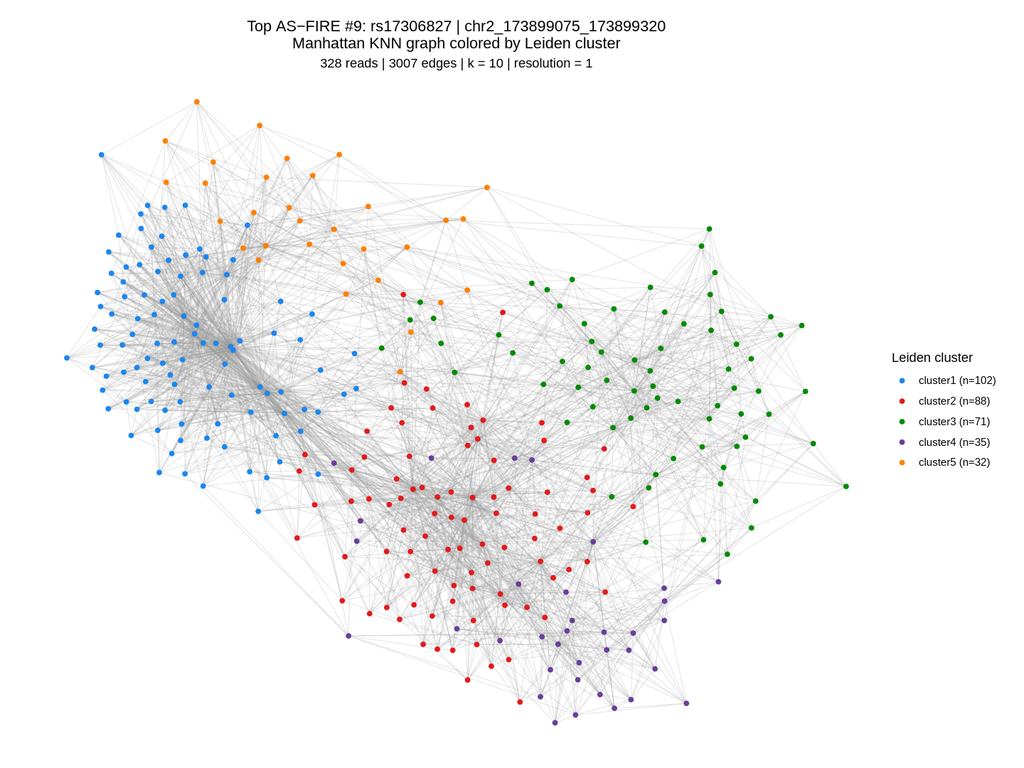

rank09_rs17306827_chr2_173899075_173899320 — Manhattan KNN graphs colored by Leiden cluster

Download original PDF: knn_graph

### rank10_rs2210798_chr6_8481830_8482016

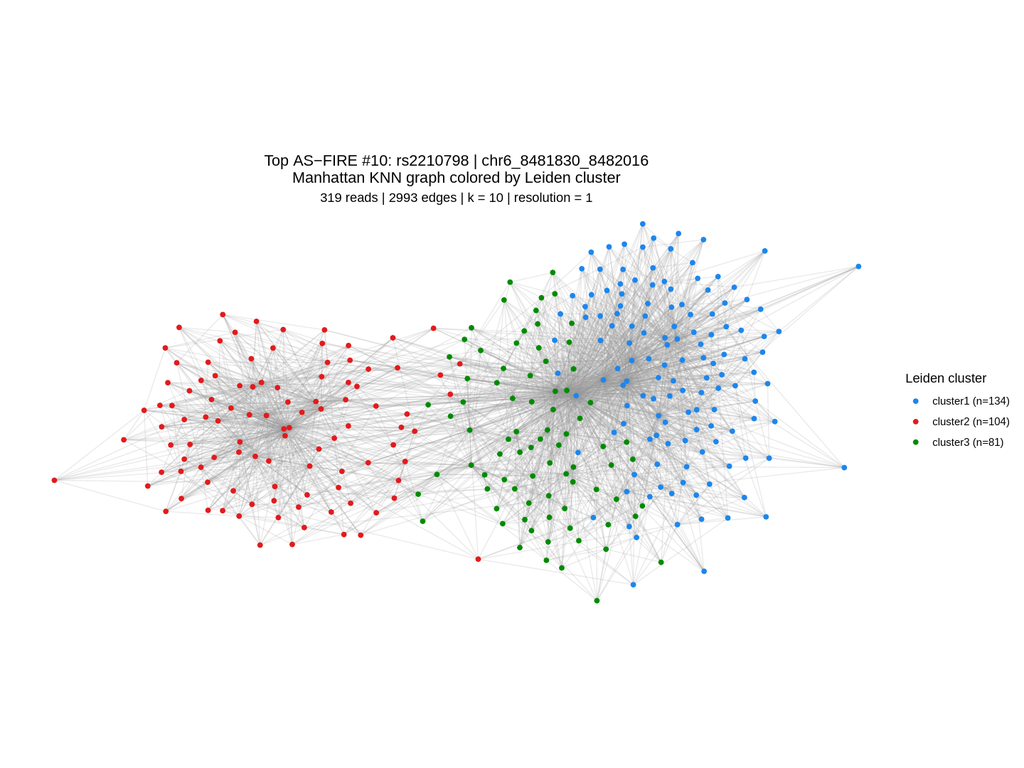

rank10_rs2210798_chr6_8481830_8482016 — Manhattan KNN graphs colored by Leiden cluster

Download original PDF: knn_graph

# KNN graph colored by haplotype

Within each group of connected reads in the KNN graph, what fraction carries each lead SNP allele?

```r
for (rid in names(knn_haplotype_views)) {
  result <- knn_haplotype_views[[rid]]$result
  plot_dir <- lcl_output_path(file.path(dirname(dirname(result_paths[[rid]])), "plots"))
  dir.create(plot_dir, recursive = TRUE, showWarnings = FALSE)
  ggplot2::ggsave(file.path(plot_dir, "knn_graph_by_allele.pdf"),
    plot_knn_graph(result, color_by = "allele"), width = 12, height = 9, bg = "white")
}
figure_gallery("knn_graph_by_allele", "KNN graph colored by focal SNP allele")
```

## KNN graph colored by focal SNP allele

### rank01_rs12470189_chr2_119290945_119291178

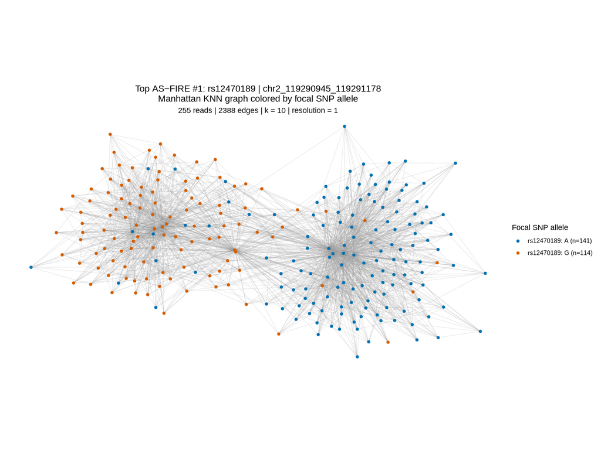

rank01_rs12470189_chr2_119290945_119291178 — KNN graph colored by focal SNP allele

Download original PDF: knn_graph_by_allele

### rank02_rs2236610_chr21_34688259_34688428

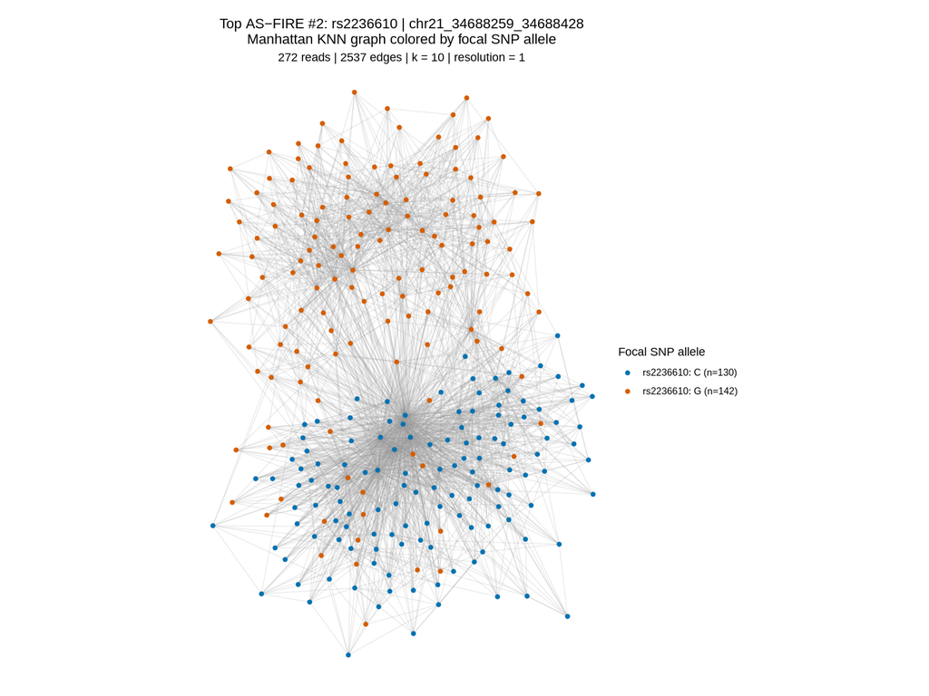

rank02_rs2236610_chr21_34688259_34688428 — KNN graph colored by focal SNP allele

Download original PDF: knn_graph_by_allele

### rank03_rs4061832_chr3_98334086_98334294

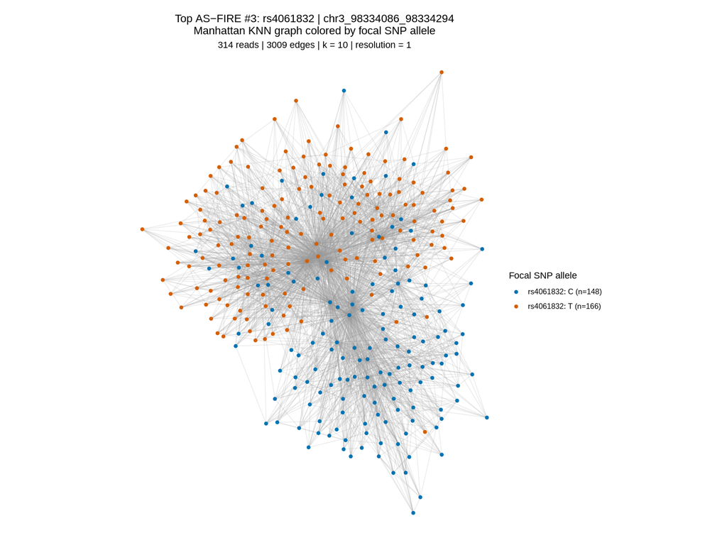

rank03_rs4061832_chr3_98334086_98334294 — KNN graph colored by focal SNP allele

Download original PDF: knn_graph_by_allele

### rank04_rs170738_chr5_55421001_55421578

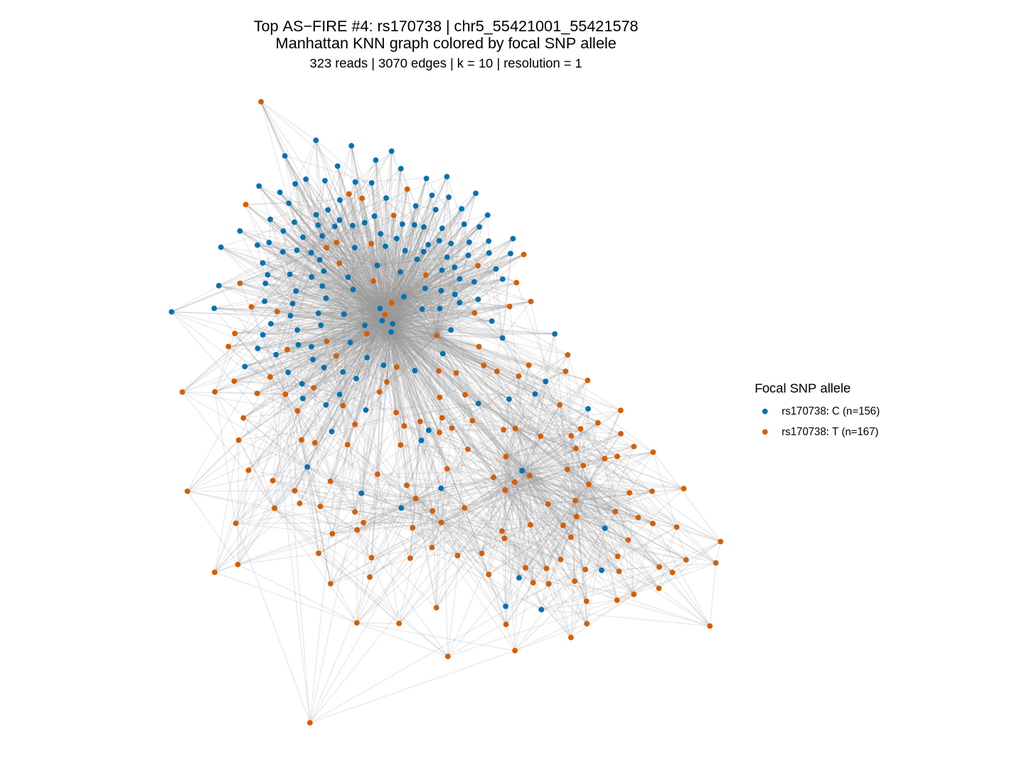

rank04_rs170738_chr5_55421001_55421578 — KNN graph colored by focal SNP allele

Download original PDF: knn_graph_by_allele

### rank05_rs1457288_chr8_109521517_109521780

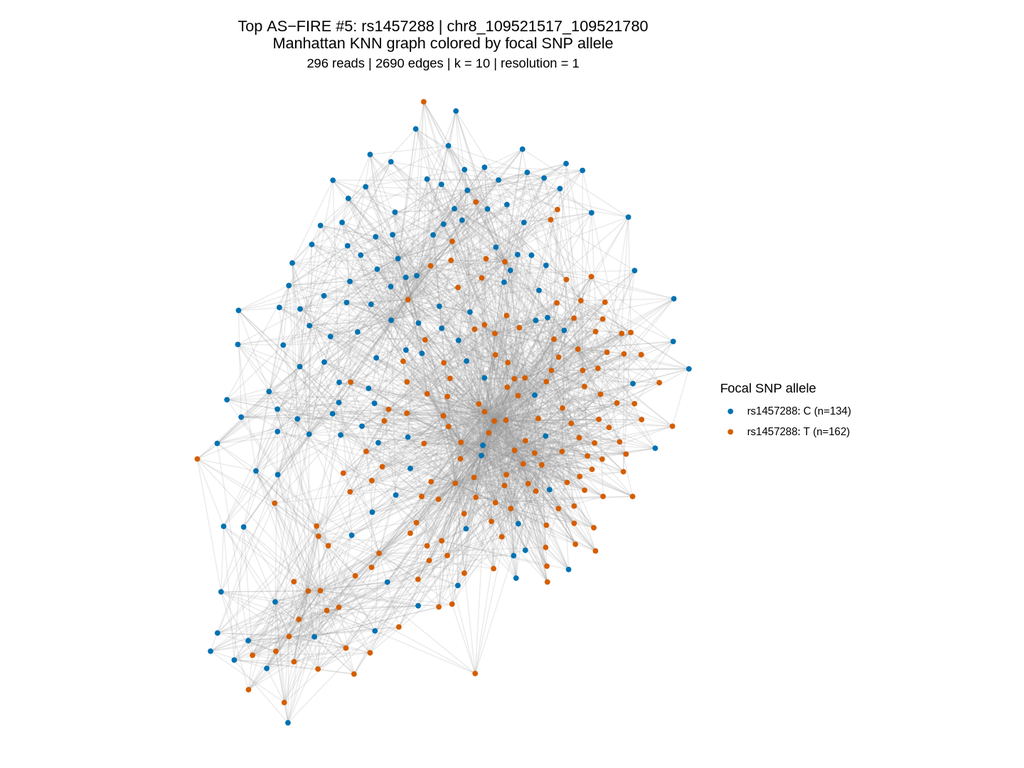

rank05_rs1457288_chr8_109521517_109521780 — KNN graph colored by focal SNP allele

Download original PDF: knn_graph_by_allele

### rank06_rs10826861_chr10_30751957_30752154

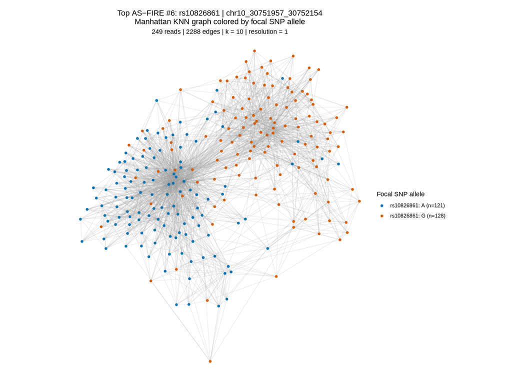

rank06_rs10826861_chr10_30751957_30752154 — KNN graph colored by focal SNP allele

Download original PDF: knn_graph_by_allele

### rank07_rs1999686_chr9_31146879_31147088

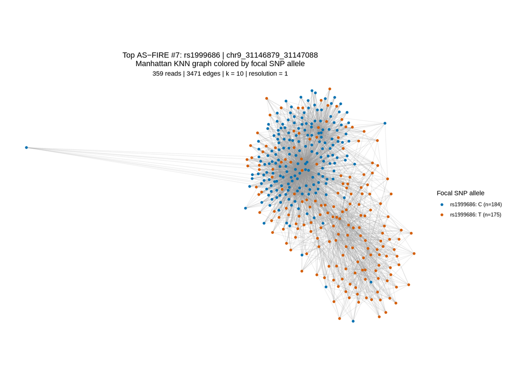

rank07_rs1999686_chr9_31146879_31147088 — KNN graph colored by focal SNP allele

Download original PDF: knn_graph_by_allele

### rank08_rs12666349_chr7_31688407_31688773

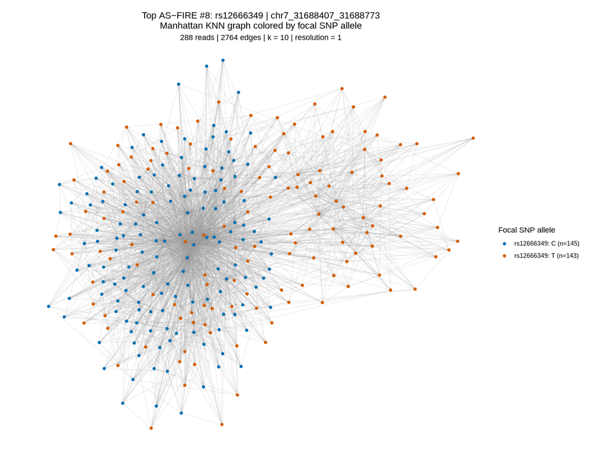

rank08_rs12666349_chr7_31688407_31688773 — KNN graph colored by focal SNP allele

Download original PDF: knn_graph_by_allele

### rank09_rs17306827_chr2_173899075_173899320

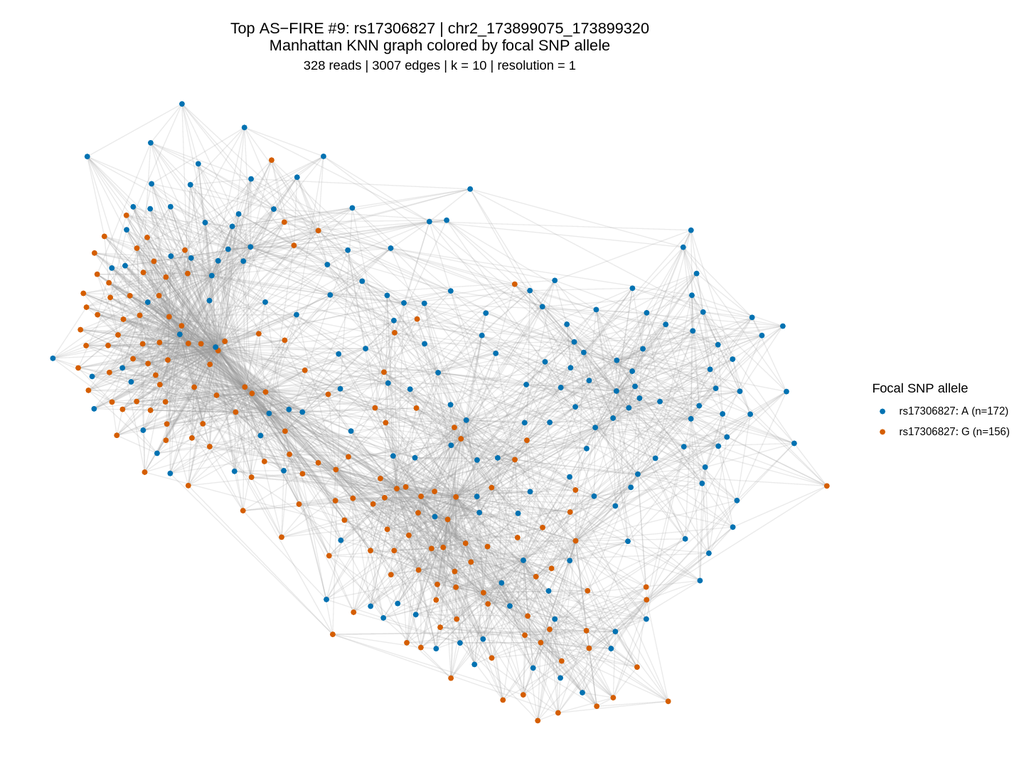

rank09_rs17306827_chr2_173899075_173899320 — KNN graph colored by focal SNP allele

Download original PDF: knn_graph_by_allele

### rank10_rs2210798_chr6_8481830_8482016

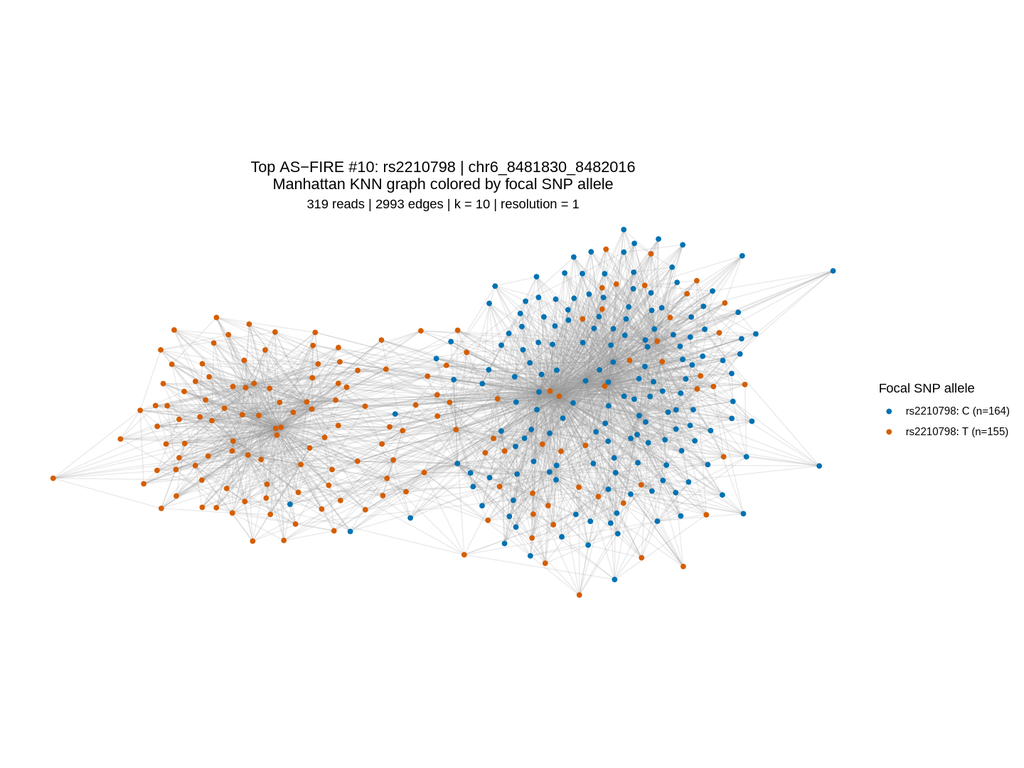

rank10_rs2210798_chr6_8481830_8482016 — KNN graph colored by focal SNP allele

Download original PDF: knn_graph_by_allele

```r
source("/project/spott/cshan/fiber-seq/code/parsing_functions/plotting_functions.r", local = TRUE)
for (rid in names(knn_haplotype_views)) {
  summary <- knn_haplotype_views[[rid]]$summary
  plot_dir <- lcl_output_path(file.path(dirname(dirname(result_paths[[rid]])), "plots"))
  ggplot2::ggsave(file.path(plot_dir, "knn_allele_composition.pdf"),
    plot_stacked_proportion(summary$composition, "group", "allele",
      fiberseq_category_palette(summary$allele_levels), y = "fraction",
      position = "stack", reverse = TRUE, width = .75, legend = list(drop = FALSE),
      scales = list(ggplot2::scale_x_discrete(labels = function(x) paste0(x, "\n(n=",
        tapply(summary$composition$n_reads, summary$composition$group, sum)[x], ")")),
        ggplot2::scale_y_continuous(labels = scales::percent, limits = c(0, 1),
          expand = ggplot2::expansion(mult = c(0, .02)))),
      labels = list(title = paste(rid, "Focal SNP allele proportions", sep = "\n"), x = "Leiden cluster", y = "Proportion of retained reads",
        fill = "Focal SNP allele", subtitle = "All reads: region-wide baseline; each bar sums to 100%",
        inside = list(min_fraction = .05, accuracy = 1, vjust = .5, color = "white", size = 3)),
      theme = ggplot2::theme_bw(base_size = 11) +
        ggplot2::theme(axis.text.x = ggplot2::element_text(angle = 45, hjust = 1))),
    width = max(10, 0.7 * nlevels(summary$composition$group) + 3), height = 6, bg = "white")
}
figure_gallery("knn_allele_composition", "Focal SNP allele proportions within each Leiden cluster")
```

## Focal SNP allele proportions within each Leiden cluster

### rank01_rs12470189_chr2_119290945_119291178

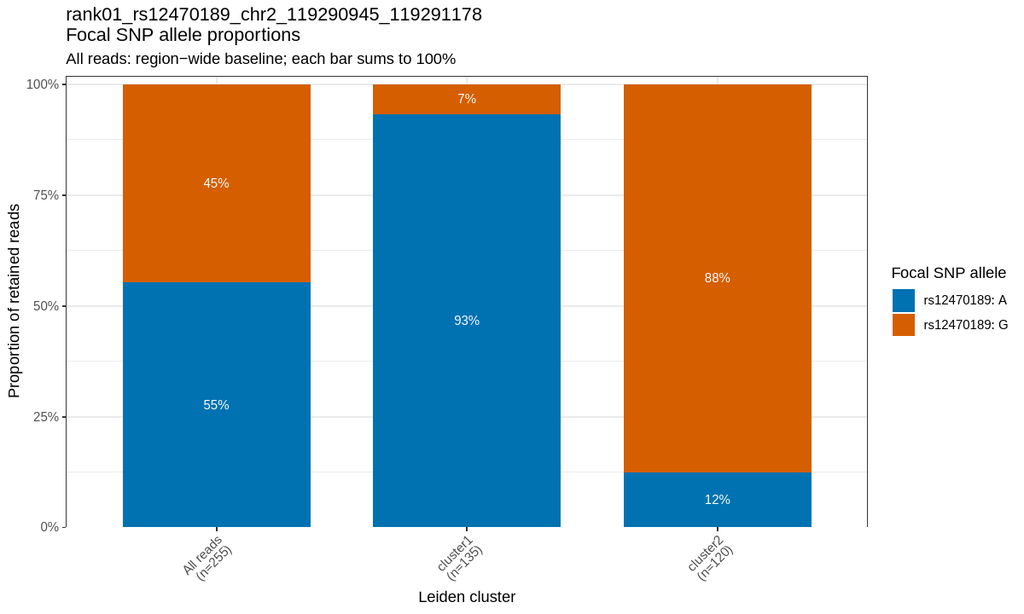

rank01_rs12470189_chr2_119290945_119291178 — Focal SNP allele proportions within each Leiden cluster

Download original PDF: knn_allele_composition

### rank02_rs2236610_chr21_34688259_34688428

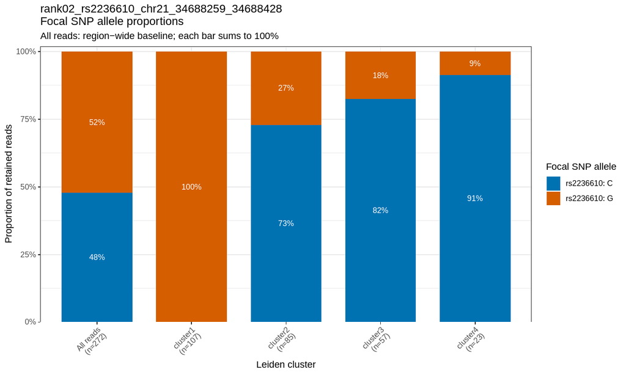

rank02_rs2236610_chr21_34688259_34688428 — Focal SNP allele proportions within each Leiden cluster

Download original PDF: knn_allele_composition

### rank03_rs4061832_chr3_98334086_98334294

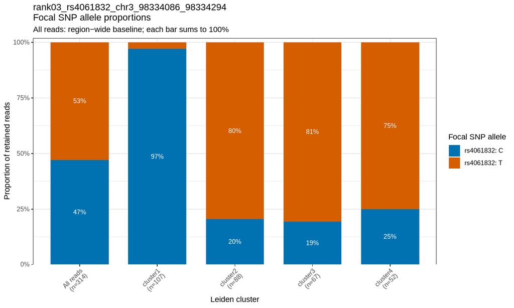

rank03_rs4061832_chr3_98334086_98334294 — Focal SNP allele proportions within each Leiden cluster

Download original PDF: knn_allele_composition

### rank04_rs170738_chr5_55421001_55421578

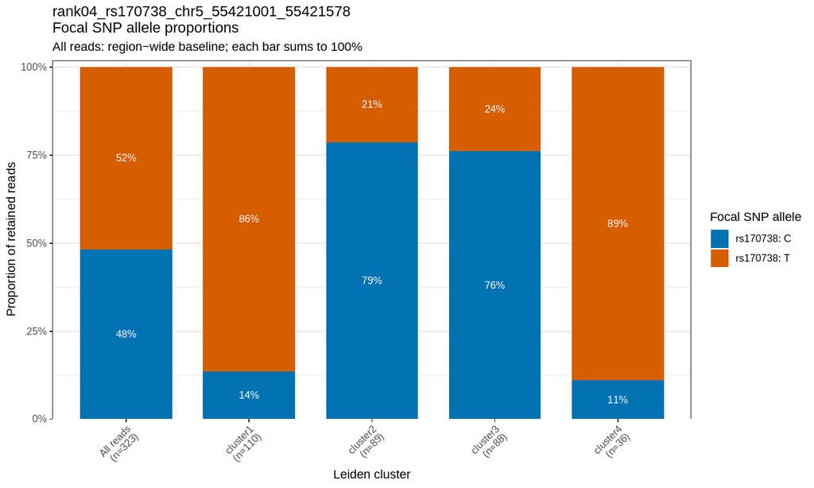

rank04_rs170738_chr5_55421001_55421578 — Focal SNP allele proportions within each Leiden cluster

Download original PDF: knn_allele_composition

### rank05_rs1457288_chr8_109521517_109521780

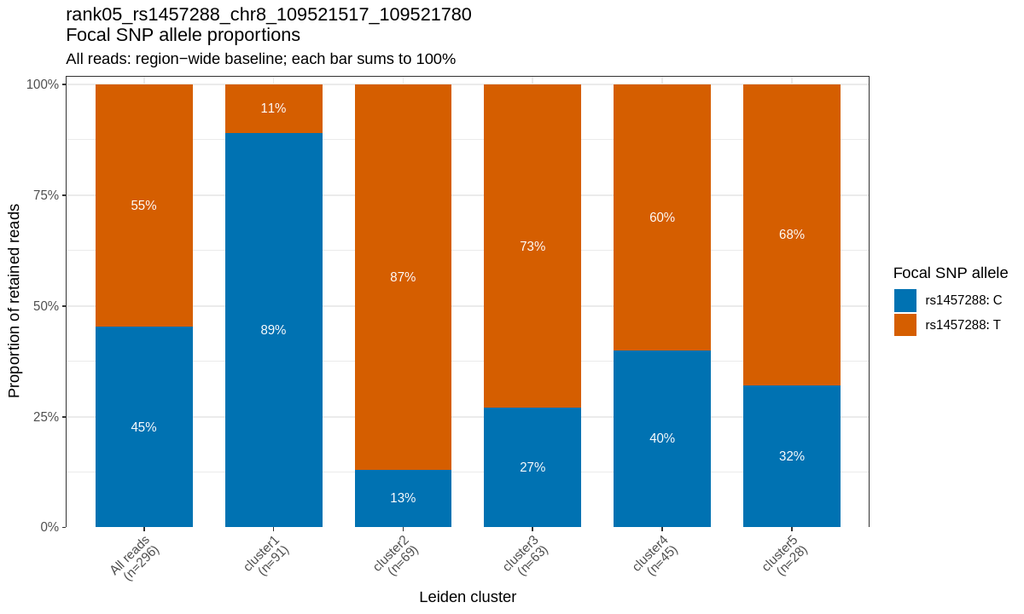

rank05_rs1457288_chr8_109521517_109521780 — Focal SNP allele proportions within each Leiden cluster

Download original PDF: knn_allele_composition

### rank06_rs10826861_chr10_30751957_30752154

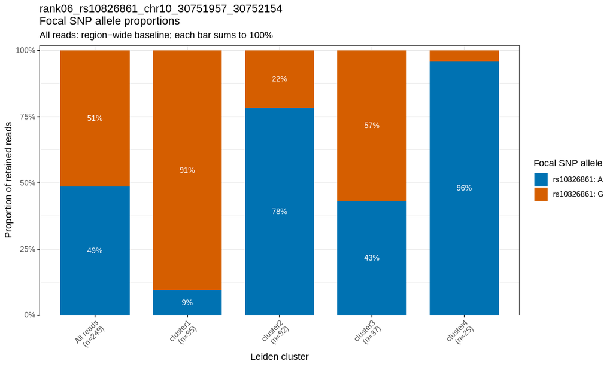

rank06_rs10826861_chr10_30751957_30752154 — Focal SNP allele proportions within each Leiden cluster

Download original PDF: knn_allele_composition

### rank07_rs1999686_chr9_31146879_31147088

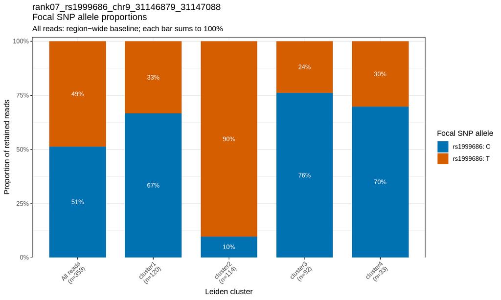

rank07_rs1999686_chr9_31146879_31147088 — Focal SNP allele proportions within each Leiden cluster

Download original PDF: knn_allele_composition

### rank08_rs12666349_chr7_31688407_31688773

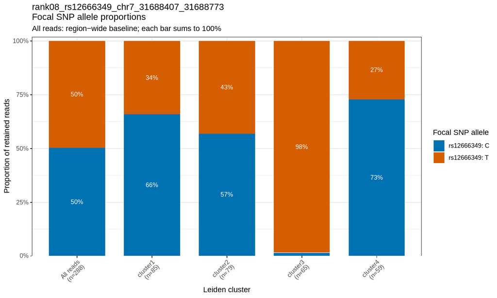

rank08_rs12666349_chr7_31688407_31688773 — Focal SNP allele proportions within each Leiden cluster

Download original PDF: knn_allele_composition

### rank09_rs17306827_chr2_173899075_173899320

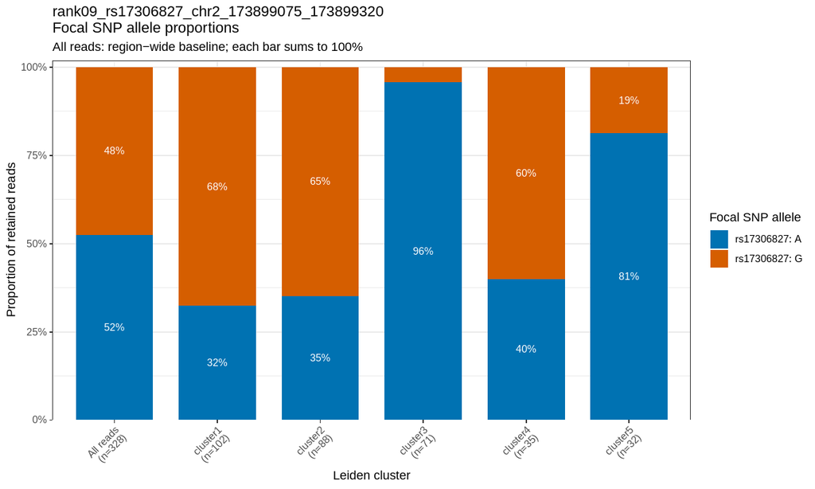

rank09_rs17306827_chr2_173899075_173899320 — Focal SNP allele proportions within each Leiden cluster

Download original PDF: knn_allele_composition

### rank10_rs2210798_chr6_8481830_8482016

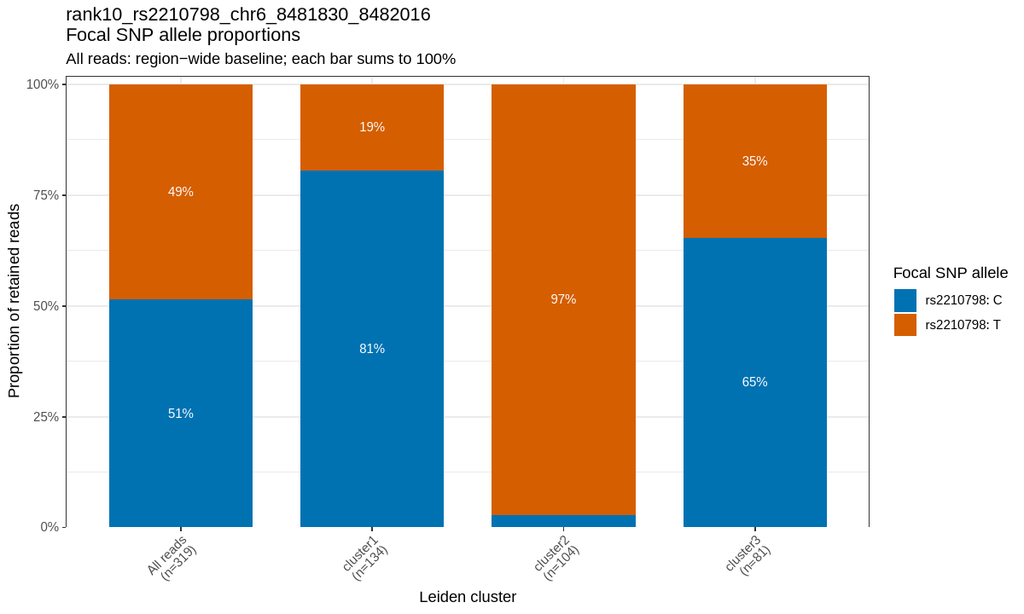

rank10_rs2210798_chr6_8481830_8482016 — Focal SNP allele proportions within each Leiden cluster

Download original PDF: knn_allele_composition

```r
for (rid in names(knn_haplotype_views)) {
  summary <- knn_haplotype_views[[rid]]$summary
  plot_dir <- lcl_output_path(file.path(dirname(dirname(result_paths[[rid]])), "plots"))
  ggplot2::ggsave(file.path(plot_dir, "knn_allele_connectivity.pdf"),
    plot_knn_allele_connectivity(summary, paste(rid, "Allele mixing in the KNN graph", sep = "\n")),
    width = 11, height = 7, bg = "white")
}
figure_gallery("knn_allele_connectivity", "Same- versus opposite-allele graph connectivity")
```

## Same- versus opposite-allele graph connectivity

### rank01_rs12470189_chr2_119290945_119291178

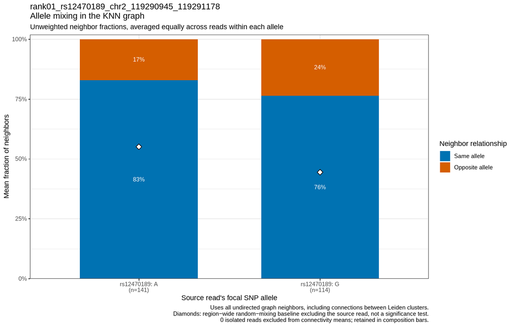

rank01_rs12470189_chr2_119290945_119291178 — Same- versus opposite-allele graph connectivity

Download original PDF: knn_allele_connectivity

### rank02_rs2236610_chr21_34688259_34688428

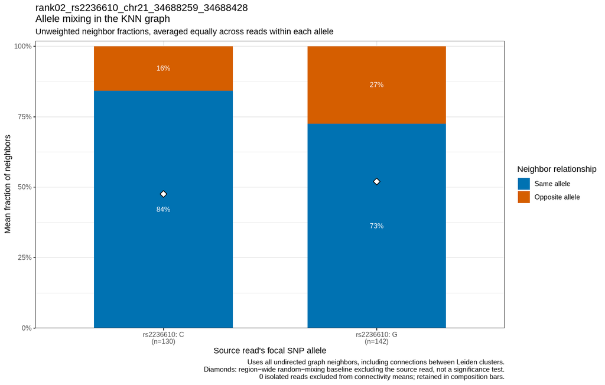

rank02_rs2236610_chr21_34688259_34688428 — Same- versus opposite-allele graph connectivity

Download original PDF: knn_allele_connectivity

### rank03_rs4061832_chr3_98334086_98334294

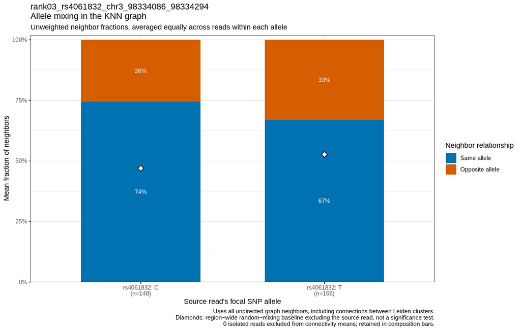

rank03_rs4061832_chr3_98334086_98334294 — Same- versus opposite-allele graph connectivity

Download original PDF: knn_allele_connectivity

### rank04_rs170738_chr5_55421001_55421578

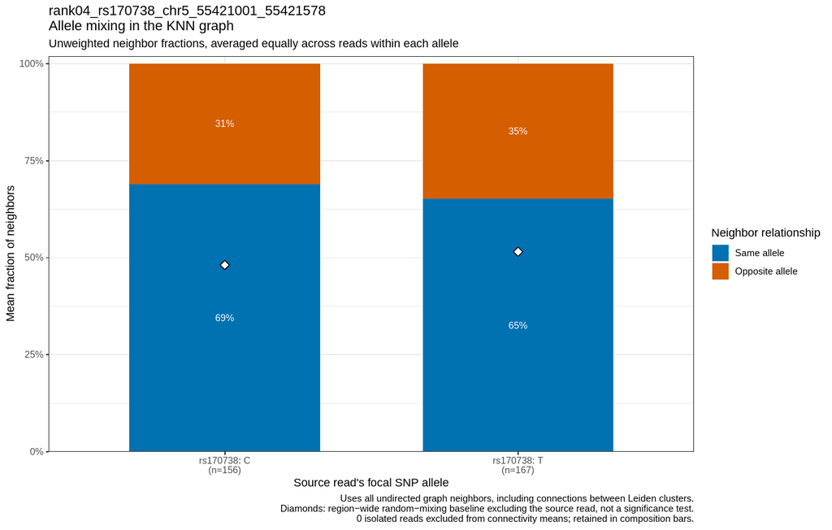

rank04_rs170738_chr5_55421001_55421578 — Same- versus opposite-allele graph connectivity

Download original PDF: knn_allele_connectivity

### rank05_rs1457288_chr8_109521517_109521780

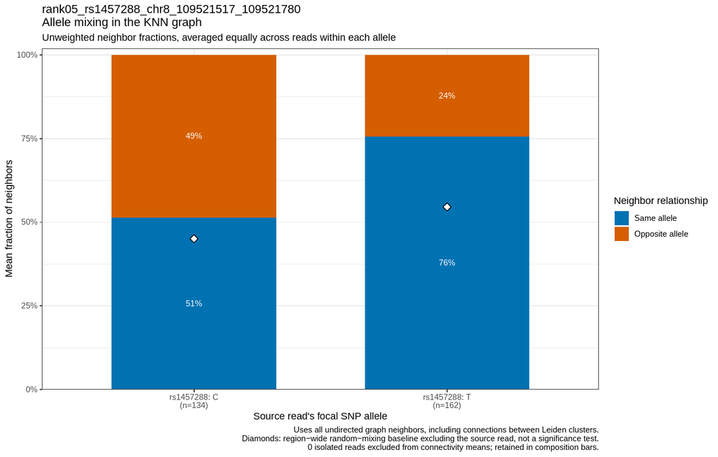

rank05_rs1457288_chr8_109521517_109521780 — Same- versus opposite-allele graph connectivity

Download original PDF: knn_allele_connectivity

### rank06_rs10826861_chr10_30751957_30752154

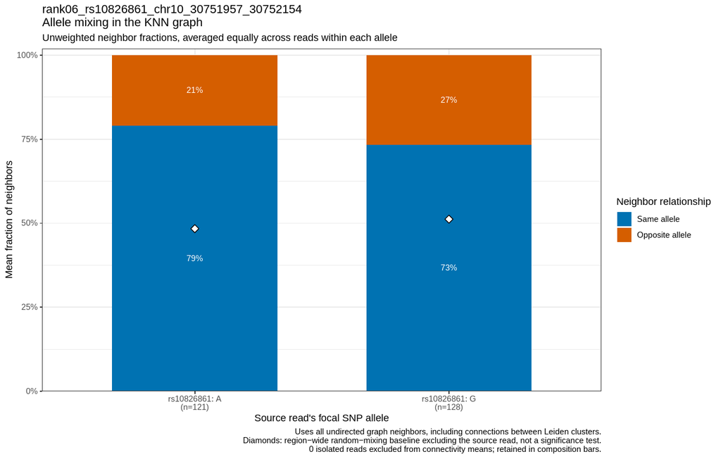

rank06_rs10826861_chr10_30751957_30752154 — Same- versus opposite-allele graph connectivity

Download original PDF: knn_allele_connectivity

### rank07_rs1999686_chr9_31146879_31147088

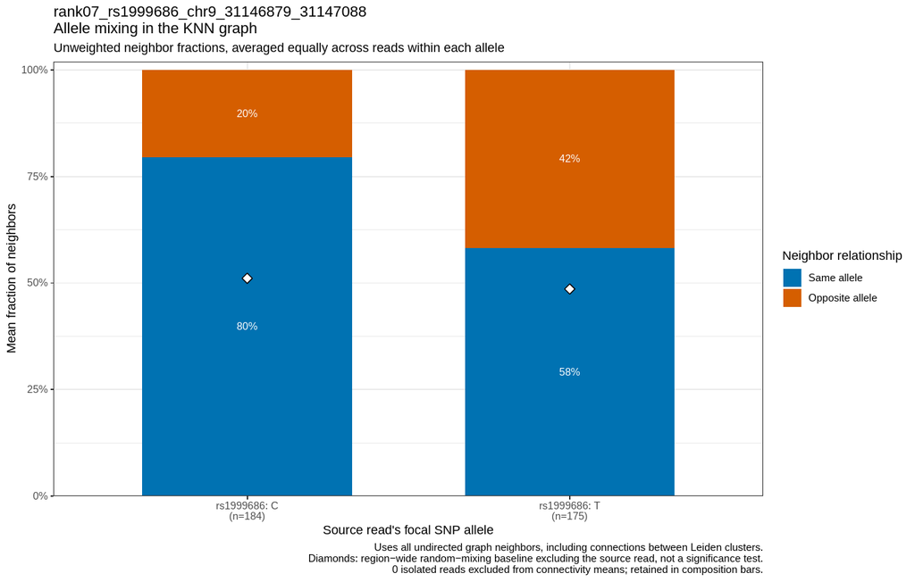

rank07_rs1999686_chr9_31146879_31147088 — Same- versus opposite-allele graph connectivity

Download original PDF: knn_allele_connectivity

### rank08_rs12666349_chr7_31688407_31688773

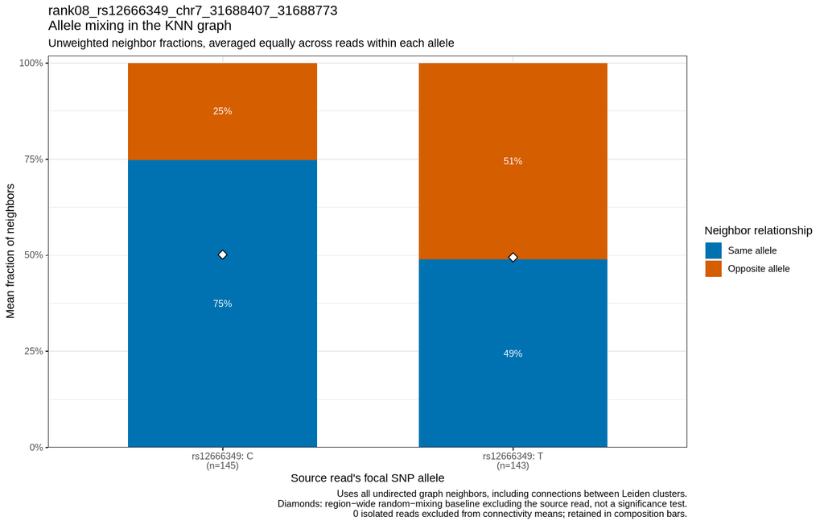

rank08_rs12666349_chr7_31688407_31688773 — Same- versus opposite-allele graph connectivity

Download original PDF: knn_allele_connectivity

### rank09_rs17306827_chr2_173899075_173899320

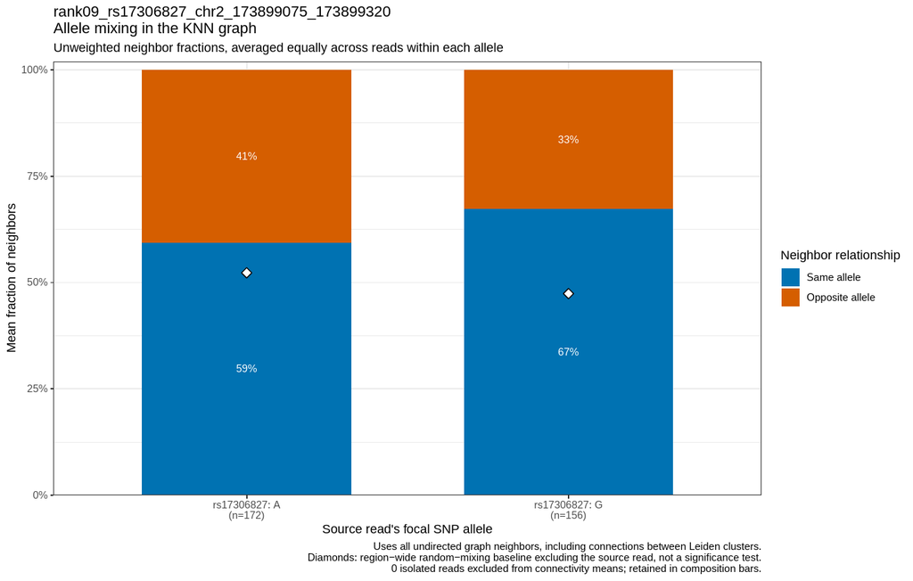

rank09_rs17306827_chr2_173899075_173899320 — Same- versus opposite-allele graph connectivity

Download original PDF: knn_allele_connectivity

### rank10_rs2210798_chr6_8481830_8482016

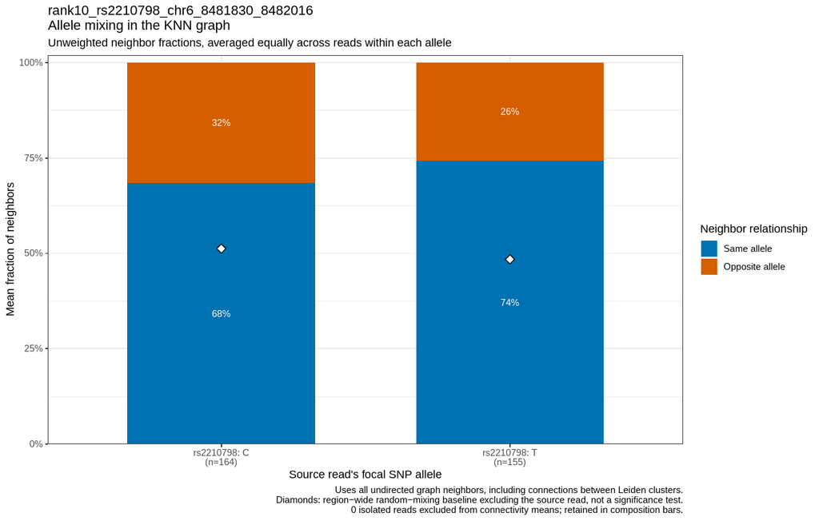

rank10_rs2210798_chr6_8481830_8482016 — Same- versus opposite-allele graph connectivity

Download original PDF: knn_allele_connectivity

# AS-FIRE promoter examples: ranks 1, 2 and 5

These figures retain the saved examples’ SNP-centred, 2 kb windows. The aggregate analysis pools **every fully spanning read from all 31 LCL samples**, without genotype or phasing filters, and reclusters with site-level Manhattan distance, `k = 10`, Leiden resolution 1 and seed 1. Panels B and D contain the same molecules in the same order (cluster, alignment start, read ID). Accessibility is the m6A call fraction at each observed site, with every read in the group in the denominator. Nucleosome occupancy is the per-base fraction of group reads covered by a fibertools footprint **strictly longer than 100 bp**, without an upper size limit. TF tracks retain the existing FiberHMM 10–30, 40–60 and 60–80 bp definitions.

The allele-specific figures use the saved, phased heterozygous AS-FIRE reads and their saved clusters. Hap1 and Hap2 denote the first and second **focal-SNP allele groups in the existing heatmap**, with the SNP base and REF/ALT identity written on each panel; they do not denote sample-local HP1/HP2 tags. Allele summaries include all reads in that allele group, including reads with no footprint.

```r
source("/project/spott/cshan/fiber-seq/code/parsing_functions/plotting_functions.r", local = TRUE)
local({
  grDevices::pdf(NULL)
  device <- grDevices::dev.cur()
  on.exit(grDevices::dev.off(device))
  for (input in example_inputs) {
    result <- input$pooled
    region <- result$region
    directory <- lcl_output_path(file.path(example_root, "aggregate_ex", region$region_id))
    dir.create(file.path(directory, "tables"), recursive = TRUE, showWarnings = FALSE)
    n <- nrow(result$assignments)
    title <- paste0("AS-FIRE rank ", region$rank, " | ", region$focal_snp)
    subtitle <- paste0(title, " | ", n, " full-span reads; all 31 samples pooled")
    message("Aggregate panels: ", region$region_id, " (", n, " reads)")
    all_reads <- result
    all_reads$assignments$cluster <- factor(rep("All reads", n))
    aggregate_profile <- example_m6a_profile(all_reads)
    cluster_profiles <- example_m6a_profile(result)
    occupancy <- footprint_profiles(input$footprints, "ft_nuc_gt100bp",
      result$assignments, region)
    aggregate_occupancy <- footprint_profiles(input$footprints, "ft_nuc_gt100bp",
      all_reads$assignments, region)
    read_order <- example_read_order(result, input$footprints)
    heatmap_height <- max(7, 0.012 * n + 2)
    footprint_height <- max(7, 0.018 * n + 3)
    profile_height <- 1.4 * result$n_clusters + 2.5
    profile_specs <- list(
      A = list(data = aggregate_profile, title = "A  Aggregate accessibility",
        y = "Fraction of reads with m6A"),
      C = list(data = cluster_profiles, title = "C  Cluster-specific accessibility",
        y = "Fraction of cluster reads with m6A"),
      E = list(data = occupancy, title = "E  Cluster-specific nucleosome occupancy (>100 bp)",
        y = "Fraction of cluster reads occupied"),
      combined_accessibility = list(data = dplyr::bind_rows(aggregate_profile, cluster_profiles),
        title = "Aggregate and cluster-specific accessibility", y = "Fraction of group reads with m6A"),
      combined_occupancy = list(data = dplyr::bind_rows(aggregate_occupancy, occupancy),
        title = "Aggregate and cluster-specific nucleosome occupancy (>100 bp)",
        y = "Fraction of group reads occupied"))
    profile_panels <- lapply(profile_specs, function(spec) {
      stopifnot(length(unique(spec$data$track)) == 1L)
      d <- signal_profile_inputs(spec$data, result$region,
        unique(as.character(spec$data$cluster)), example_plotters$LCL_TRACK_COLORS)
      anchor <- plot_anchor(result$region)
      colors <- c("All reads" = "#333333", cluster_id_palette(levels(result$assignments$cluster)))
      counts <- unique(d[, c("cluster", "n_reads")])
      labels <- setNames(paste0(counts$cluster, " (n=", counts$n_reads, ")"), counts$cluster)
      plot_group_profile(d, group_col = "cluster", style = "ribbon", x_col = "relative_pos",
        mapping = ggplot2::aes(relative_pos, fraction, fill = cluster, color = cluster, group = cluster),
        layers = list(list(geom = "ribbon",
          data = d[d$track %in% "ft_nuc_130-160bp", , drop = FALSE],
          mapping = ggplot2::aes(ymin = 0, ymax = fraction), fill = "grey60", color = NA, alpha = .18),
          list(geom = "line", linewidth = .5)),
        colors = colors, fill_colors = colors) +
        ggplot2::facet_wrap(~cluster, ncol = 1, labeller = ggplot2::as_labeller(labels)) +
        ggplot2::geom_vline(xintercept = 0, linetype = "dashed", color = "grey30", linewidth = .4) +
        ggplot2::scale_x_continuous(limits = c(anchor$left - .5, anchor$right + .5), expand = c(0, 0)) +
        ggplot2::scale_y_continuous(limits = c(0, 1), breaks = c(0, .5, 1),
          expand = ggplot2::expansion(mult = c(0, .02))) +
        ggplot2::labs(x = anchor$x_label, y = spec$y, title = spec$title, subtitle = subtitle,
          fill = "Plot track", color = "Plot track") +
        cowplot::theme_cowplot(font_size = 10) + cowplot::panel_border() +
        ggplot2::guides(fill = ggplot2::guide_legend(ncol = 4), color = ggplot2::guide_legend(ncol = 4)) +
        ggplot2::theme(legend.position = "none", legend.text = ggplot2::element_text(size = 8),
          plot.margin = ggplot2::margin(5.5, 16, 5.5, 5.5))
    })
    panels <- list(
      A = profile_panels$A + ggplot2::facet_null(),
      B = example_heatmap(result, paste0("B  Raw m6A reads ordered by Leiden cluster\n", subtitle),
        heatmap_height),
      C = profile_panels$C,
      D = example_plotters$plot_smf_reads(result, input$footprints, example_sample_colors,
        include_haplotype = FALSE) + ggplot2::labs(
          title = "D  Same molecules: nucleosome and TF footprints", subtitle = subtitle),
      E = profile_panels$E)
    filenames <- c("A_aggregate_accessibility", "B_raw_m6a_by_Leiden_cluster",
      "C_cluster_accessibility", "D_nucleosome_TF_fibers", "E_nucleosome_occupancy_gt100bp")
    heights <- c(3.5, heatmap_height, profile_height, footprint_height, profile_height)
    for (j in seq_along(panels)) example_save(panels[[j]], directory, filenames[j], heights[j])
    # Capture the heatmap at its final panel height: its legends use absolute
    # units and otherwise spill into adjacent panels when the grob is resized.
    combined_panels <- panels
    combined_panels$B <- example_heatmap(result,
      paste0("B  Raw m6A reads ordered by Leiden cluster\n", subtitle), 6)
    combined <- cowplot::plot_grid(plotlist = combined_panels, ncol = 1,
      rel_heights = c(2.5, 6, profile_height, 6, profile_height))
    example_save(combined, directory, "aggregate_A-E", 14.5 + 2 * profile_height)
    example_save(profile_panels$combined_accessibility, directory,
      "aggregate_and_cluster_accessibility", profile_height + 1.4)
    example_save(profile_panels$combined_occupancy, directory,
      "aggregate_and_cluster_nucleosome_occupancy_gt100bp", profile_height + 1.4)
    data.table::fwrite(read_order, file.path(directory, "tables", "molecule_order.tsv"), sep = "\t")
    data.table::fwrite(input$qc, file.path(directory, "tables", "all_31_samples_read_qc.tsv"), sep = "\t")
    data.table::fwrite(dplyr::bind_rows(
      transform(aggregate_profile, panel = "A"), transform(cluster_profiles, panel = "C"),
      transform(occupancy, panel = "E"), transform(aggregate_occupancy, panel = "aggregate_nucleosome")),
      file.path(directory, "tables", "profiles.tsv"), sep = "\t")
    saveRDS(result, file.path(directory, "tables", "all_reads_clustering.rds"))
    stopifnot(nrow(read_order) == n, all(is.finite(occupancy$fraction)),
      all(occupancy$fraction >= 0 & occupancy$fraction <= 1))
  }
})
```

```r
local({
  grDevices::pdf(NULL)
  device <- grDevices::dev.cur()
  on.exit(grDevices::dev.off(device))
  audit <- list()
  for (input in example_inputs) {
    result <- fiberseq_display_result(input$saved)
    region <- result$region
    directory <- lcl_output_path(file.path(example_root, "hap_ex", region$region_id))
    dir.create(file.path(directory, "tables"), recursive = TRUE, showWarnings = FALSE)
    alleles <- result$allele_display_levels
    stopifnot(length(alleles) == 2L, all(result$assignments$haplotype %in% c("HP1", "HP2")),
      all(result$assignments$focal_genotype %in% c("0|1", "1|0")))
    bases <- sub("^.*: ", "", alleles)
    labels <- paste0("Hap", 1:2, ": ", bases,
      ifelse(bases == region$ref, " (REF)", " (ALT)"))
    colors <- setNames(unname(fiberseq_category_palette(alleles)), labels)
    counts <- vapply(alleles, function(a) sum(result$assignments$allele_display == a), integer(1))
    title <- paste0("AS-FIRE rank ", region$rank, " | ", region$focal_snp)
    subtitle <- paste0(title, " | ", paste0(labels, ", n=", counts, collapse = "; "))
    message("Allele panels: ", region$region_id)
    allele_result <- result
    allele_result$assignments$cluster <- factor(
      labels[match(as.character(result$assignments$allele_display), alleles)], levels = labels)
    footprints <- input$footprints[input$footprints$RID %in% result$assignments$RID, , drop = FALSE]
    accessibility <- example_m6a_profile(allele_result)
    occupancy <- footprint_profiles(footprints, example_plotters$LCL_FOOTPRINT_TRACKS,
      allele_result$assignments, region)
    occupancy$track <- factor(occupancy$track, levels = example_plotters$LCL_FOOTPRINT_TRACKS)
    overlay <- function(profiles, heading, y_label) {
      anchor <- plot_anchor(region)
      profiles$relative_pos <- profiles$pos - anchor$anchor
      profiles$cluster <- factor(profiles$cluster, levels = labels)
      profiles <- profiles[order(profiles$cluster, profiles$track, profiles$pos), ]
      ggplot2::ggplot(profiles, ggplot2::aes(relative_pos, fraction, color = cluster)) +
        ggplot2::geom_line(linewidth = 0.55) +
        ggplot2::geom_vline(xintercept = 0, linetype = "dashed", color = "grey40") +
        ggplot2::scale_color_manual(values = colors, drop = FALSE) +
        ggplot2::scale_x_continuous(limits = c(anchor$left, anchor$right), expand = c(0, 0)) +
        ggplot2::scale_y_continuous(limits = c(0, 1), breaks = c(0, 0.5, 1)) +
        ggplot2::labs(title = heading, subtitle = subtitle, x = anchor$x_label,
          y = y_label, color = "Focal-SNP allele group") +
        cowplot::theme_cowplot(font_size = 10) + cowplot::panel_border() +
        ggplot2::theme(legend.position = "bottom")
    }
    views <- lapply(alleles, function(allele) example_subset(result,
      result$assignments$RID[result$assignments$allele_display == allele]))
    panels <- list(
      A = overlay(accessibility, "A  Haplotype-specific aggregate accessibility",
        "Fraction of allele-group reads with m6A"),
      B = example_heatmap(views[[1L]], paste0("B  ", labels[1L], " individual chromatin fibers\n",
        title, " | n=", counts[1L], "; saved Leiden clusters"), 7),
      C = example_heatmap(views[[2L]], paste0("C  ", labels[2L], " individual chromatin fibers\n",
        title, " | n=", counts[2L], "; saved Leiden clusters"), 7),
      D = overlay(occupancy, "D  Haplotype-specific nucleosome and TF occupancy",
        "Fraction of allele-group reads occupied") +
        ggplot2::facet_wrap(~track, ncol = 1,
          labeller = ggplot2::as_labeller(example_plotters$LCL_TRACK_LABELS)))
    filenames <- c("A_haplotype_accessibility", "B_Hap1_m6a_fibers", "C_Hap2_m6a_fibers",
      "D_haplotype_nucleosome_TF_occupancy")
    heights <- c(4, 7, 7, 8)
    for (j in seq_along(panels)) example_save(panels[[j]], directory, filenames[j], heights[j])
    combined_panels <- panels
    for (j in 1:2) combined_panels[[j + 1L]] <- example_heatmap(views[[j]],
      paste0(LETTERS[j + 1L], "  ", labels[j], " individual chromatin fibers\n",
        title, " | n=", counts[j], "; saved Leiden clusters"), 6)
    example_save(cowplot::plot_grid(plotlist = combined_panels, ncol = 1,
      rel_heights = c(3, 6, 6, 7)), directory, "haplotype_A-D", 22)
    for (j in 1:2) {
      order <- example_read_order(views[[j]], footprints)
      order$allele_group <- labels[j]
      data.table::fwrite(order, file.path(directory, "tables", paste0("Hap", j, "_molecule_order.tsv")), sep = "\t")
    }
    data.table::fwrite(data.frame(allele_group = labels, allele_label = alleles,
      n_reads = counts), file.path(directory, "tables", "allele_groups.tsv"), sep = "\t")
    data.table::fwrite(dplyr::bind_rows(transform(accessibility, panel = "A"),
      transform(occupancy, panel = "D")), file.path(directory, "tables", "profiles.tsv"), sep = "\t")
    unchanged <- identical(unname(tools::md5sum(input$source_path)), input$source_md5)
    stopifnot(unchanged, sum(counts) == nrow(result$assignments),
      all(is.finite(occupancy$fraction)), all(occupancy$fraction >= 0 & occupancy$fraction <= 1))
    audit[[region$region_id]] <- data.frame(rank = region$rank, region_id = region$region_id,
      samples_queried = nrow(input$qc), samples_with_full_span_reads = sum(input$qc$full_span_reads > 0),
      aggregate_reads = nrow(input$pooled$assignments), aggregate_clusters = input$pooled$n_clusters,
      hap1_allele = alleles[1L], hap1_reads = counts[1L], hap2_allele = alleles[2L], hap2_reads = counts[2L],
      saved_clusters_unchanged = unchanged, source_md5 = input$source_md5)
  }
  audit <- dplyr::bind_rows(audit)
  data.table::fwrite(audit, file.path(example_root, "validation.tsv"), sep = "\t")
  writeLines(c("# LCL AS-FIRE examples: ranks 1, 2 and 5", "",
    "Aggregate: all fully spanning reads from all 31 LCL samples, newly clustered together.",
    "Allele-specific: saved phased heterozygous reads, grouped by focal-SNP allele as in the heatmaps.",
    "Nucleosome footprints are strictly >100 bp; the original 2 kb SNP-centred windows are retained.", "",
    "Each folder includes individual panel PDFs, combined figures, and supporting tables.",
    "The aggregate profile summaries show all reads above the clusters, with consistent cluster colors.", "",
    "| Rank | Aggregate reads | Combined aggregate | Hap1 allele (reads) | Hap2 allele (reads) | Combined allele-specific |",
    "|---|---:|---|---|---|---|",
    vapply(seq_len(nrow(audit)), function(i) {
      a <- audit[i, ]
      sprintf("| %d | %d | [PDF](aggregate_ex/%s/aggregate_A-E.pdf) | %s (%d) | %s (%d) | [PDF](hap_ex/%s/haplotype_A-D.pdf) |",
        a$rank, a$aggregate_reads, a$region_id, a$hap1_allele, a$hap1_reads,
        a$hap2_allele, a$hap2_reads, a$region_id)
    }, character(1)), "",
    "| Rank | Aggregate and cluster accessibility | Aggregate and cluster nucleosome occupancy |",
    "|---|---|---|",
    vapply(seq_len(nrow(audit)), function(i) {
      a <- audit[i, ]
      sprintf("| %d | [PDF](aggregate_ex/%s/aggregate_and_cluster_accessibility.pdf) | [PDF](aggregate_ex/%s/aggregate_and_cluster_nucleosome_occupancy_gt100bp.pdf) |",
        a$rank, a$region_id, a$region_id)
    }, character(1)), "", "See [validation.tsv](validation.tsv) for counts and saved-result checks."),
    file.path(example_root, "index.md"))
})
```

# PRDX1 and ALAS1 promoters: all reads, without haplotype information

Pool all 31 LCL samples, including samples without genotypes, and retain every read spanning the complete promoter window. No haplotype, SNP, genotype or allele filtering is applied, and reads are not downsampled. Clustering uses the existing m6A Manhattan/Leiden helpers with `window_size = 0`, `k = 10`, resolution 1 and seed 1, as in the selected AS-FIRE figures.

The canonical TSS BED encodes 1 bp intervals `[TSS, TSS + 1)` in zero-based coordinates. Use `start` as TSS0 (`start + 1` in one-based coordinates) and the exactly 2,000 bp half-open window `[TSS0 - 1000, TSS0 + 1000)`. Read-footprint and occupancy plots orient the coordinates by gene strand. Dashed lines mark the TSS (0 bp on these relative axes), including each cluster slice and m6A profile of the genomic heatmap. UMAPs and the pie chart have no genomic coordinate axis.

```r
source("/project/spott/cshan/fiber-seq/code/parsing_functions/plotting_functions.r", local = TRUE)
local({
  genes <- c("PRDX1", "ALAS1")
  tss_bed <- data.table::fread(
    "/project/spott/cshan/annotations/gencodev46_Ensembl_canonical_TSS.bed",
    header = FALSE, col.names = c("chr", "start", "end", "annotation", "score", "strand"),
    data.table = FALSE)
  tss_bed$gene <- vapply(strsplit(tss_bed$annotation, ";", fixed = TRUE), `[`, character(1), 3L)
  selected <- tss_bed[tss_bed$gene %in% genes, , drop = FALSE]
  stopifnot(nrow(selected) == length(genes), !anyDuplicated(selected$gene),
    all(selected$end - selected$start == 1L))
  selected <- selected[match(genes, selected$gene), , drop = FALSE]
  tss0 <- selected$start
  promoters <- data.frame(region_id = genes, gene = genes, chr = selected$chr,
    start = tss0 - 1000L, end = tss0 + 1000L,
    analysis_start = tss0 - 999L, analysis_end = tss0 + 1000L,
    width = 2000L, tss = tss0 + 1L, strand = selected$strand,
    region_type = "promoter", annotation = paste(genes, "canonical promoter"))
  stopifnot(all(promoters$analysis_end - promoters$analysis_start + 1L == 2000L))

  # Read the complete sample table afresh, independently of AS-FIRE contributors.
  samples <- read.csv(
    "/project/spott/1_Shared_projects/LCL_Fiber_seq/Data/LCL_sample_metatable_merged_samples_31samples.csv",
    stringsAsFactors = FALSE)[, c("sample_name", "fire_dir")]
  stopifnot(!anyDuplicated(samples$sample_name),
    !anyDuplicated(sub("_.*$", "", samples$sample_name)))
  sample_colors <- sample_palette(samples$sample_name)
  full_colors <- setNames(unname(sample_colors[sub("_.*$", "", samples$sample_name)]), samples$sample_name)
  root <- lcl_output_path(file.path(LCL_OUTPUT_ROOT, "test_promoters"))
  dir.create(root, recursive = TRUE, showWarnings = FALSE)
  # The existing footprint extractor requires a cache; remove it after plotting
  # so the only persistent outputs are the requested PDFs.
  cache_dir <- tempfile(".footprint-cache-", tmpdir = root)
  # Plot layout helpers may open a device before export; avoid an extra Rplots.pdf.
  grDevices::pdf(NULL)
  layout_device <- grDevices::dev.cur()
  tryCatch({
    caches <- cache_footprint_tracks(promoters,
      "/project/spott/1_Shared_projects/LCL_Fiber_seq/FiberHMM/merged/combined/joint_trained_tracks",
      lcl_output_path(cache_dir), workers = 2L, reuse = FALSE)
    for (i in seq_len(nrow(promoters))) {
      region <- promoters[i, , drop = FALSE]
      dat <- assemble_region_m6a(sample_table = samples, region = region,
        full_span = TRUE, matrix_dir = NULL, reuse = FALSE)
      result <- leiden_manhattan_cluster(dat$met_mat, dat$rids_df,
        region$analysis_start, region$analysis_end, window_size = 0L,
        k_neighbors = 10L, resolution = 1, seed = 1L)
      result$region <- region
      result$site_met_mat <- dat$met_mat
      result$assignments$original_RID <- dat$rids_df$original_RID[
        match(result$assignments$RID, dat$rids_df$RID)]
      stopifnot(identical(result$assignments$RID, dat$rids_df$RID),
        nrow(result$assignments) == sum(dat$qc$full_span_reads))
      message(region$gene, ": retained all ", nrow(result$assignments),
        " full-span reads from ", length(unique(result$assignments$sample_name)), " samples")
      footprints <- dplyr::bind_rows(
        extract_nucleosomes(samples, region, result$assignments),
        region_footprints(caches, region, result$assignments)$records)
      signals <- signal_profiles(result, footprints)
      plot_dir <- lcl_output_path(file.path(root, region$gene))
      dir.create(plot_dir, recursive = TRUE, showWarnings = FALSE)

      embedding <- fiberseq_umap(result, seed = 1L)
      cluster_colors <- cluster_id_palette(levels(result$assignments$cluster))
      counts <- as.data.frame(table(result$assignments$cluster),
        responseName = "n_reads", stringsAsFactors = FALSE)
      names(counts)[1L] <- "cluster"
      counts$proportion <- counts$n_reads / sum(counts$n_reads)
      counts$label <- sprintf("%s (n=%d; %.1f%%)", counts$cluster,
        counts$n_reads, 100 * counts$proportion)
      # There is no standalone pie helper; compose it with the sourced UMAPs.
      pie <- ggplot2::ggplot(counts, ggplot2::aes(x = "", y = proportion, fill = cluster)) +
        ggplot2::geom_col(width = 1, color = "white",
          position = ggplot2::position_stack(reverse = TRUE)) +
        ggplot2::coord_polar(theta = "y") +
        ggplot2::scale_fill_manual(values = cluster_colors, breaks = counts$cluster, labels = counts$label) +
        ggplot2::labs(title = paste0("Cluster proportions: ", nrow(embedding), " reads"), fill = NULL) +
        ggplot2::theme_void() + ggplot2::theme(legend.text = ggplot2::element_text(size = 8))
      overview <- cowplot::plot_grid(
        plot_umap(embedding, "sample_name", full_colors, "UMAP: LCL sample",
          labels = sub("_.*$", "", names(full_colors)), show_legend = TRUE),
        plot_umap(embedding, "cluster", cluster_colors, "UMAP: cluster", show_legend = TRUE),
        pie, ncol = 3, rel_widths = c(1.3, 1, 1))
      ggplot2::ggsave(file.path(plot_dir, "fiberseq_haplotype_example.pdf"),
        overview, width = 20, height = 7, bg = "white")
      tss_caption <- paste0("Dashed line: canonical TSS ", region$chr, ":", region$tss, " (0 bp)")
      ggplot2::ggsave(file.path(plot_dir, "fig1_read_footprints.pdf"),
        plot_smf_reads(result, signals$records, sample_colors, include_haplotype = FALSE) +
          ggplot2::labs(caption = tss_caption),
        width = 12, height = max(7, 0.03 * nrow(result$assignments) + 3.5 + 0.3 * result$n_clusters),
        limitsize = FALSE)
      ggplot2::ggsave(file.path(plot_dir, "fig2_occupancy_by_cluster.pdf"),
        local({
          .profile_args <- list(profiles = signals$profiles,
      region = region,
      clusters = levels(result$assignments$cluster))
          profiles <- .profile_args$profiles
          region <- .profile_args$region
          clusters <- .profile_args$clusters
          title <- region$annotation
          track_colors <- LCL_TRACK_COLORS
          track_labels <- LCL_TRACK_LABELS
          nucleosome_track <- "ft_nuc_130-160bp"
          profiles <- signal_profile_inputs(profiles, region, clusters, track_colors)
          anchor <- plot_anchor(region)
          colors <- feature_colors(levels(profiles$track), track_colors)
          counts <- unique(profiles[, c("cluster", "n_reads")])
          labels <- setNames(paste0(counts$cluster, " (n=", counts$n_reads, ")"), counts$cluster)
          plot <- plot_group_profile(profiles, group_col = "track", style = "ribbon",
            x_col = "relative_pos",
            mapping = ggplot2::aes(relative_pos, fraction, fill = track, color = track, group = track),
            layers = list(list(geom = "ribbon",
              data = profiles[profiles$track %in% nucleosome_track, , drop = FALSE],
              mapping = ggplot2::aes(ymin = 0, ymax = fraction), fill = "grey60", color = NA, alpha = .18),
              list(geom = "line", linewidth = 0.5)))
          plot + ggplot2::facet_wrap(~cluster, ncol = 1, labeller = ggplot2::as_labeller(labels)) +
            ggplot2::geom_vline(xintercept = 0, linetype = "dashed", color = "grey30", linewidth = 0.4) +
            ggplot2::scale_fill_manual(values = colors, labels = track_labels) +
            ggplot2::scale_color_manual(values = colors, labels = track_labels) +
            ggplot2::scale_x_continuous(limits = c(anchor$left - 0.5, anchor$right + 0.5), expand = c(0, 0)) +
            ggplot2::scale_y_continuous(limits = c(0, 1), breaks = c(0, 0.5, 1),
              expand = ggplot2::expansion(mult = c(0, 0.02))) +
            ggplot2::labs(x = anchor$x_label, y = "Fraction of cluster reads", title = title,
              subtitle = "m6A calls and footprint occupancy; retained heterozygous reads", fill = "Plot track", color = "Plot track") +
            cowplot::theme_cowplot(font_size = 10) + cowplot::panel_border() +
            ggplot2::guides(fill = ggplot2::guide_legend(ncol = 4), color = ggplot2::guide_legend(ncol = 4)) +
            ggplot2::theme(legend.position = "bottom", legend.text = ggplot2::element_text(size = 8),
              plot.margin = ggplot2::margin(5.5, 16, 5.5, 5.5))
        }) +
          ggplot2::labs(subtitle = "m6A calls and footprint occupancy; all full-span reads",
            caption = tss_caption),
        width = 10, height = 1.4 * result$n_clusters + 2.5, limitsize = FALSE)
      heatmap <- plot_read_heatmap(result, region, sample_colors,
        include_haplotype = FALSE, variants = NULL, show_cluster_profiles = TRUE)
      grDevices::pdf(file.path(plot_dir, "heatmap_m6a_footprints.pdf"),
        width = 14, height = 11 + 0.55 * result$n_clusters)
      tryCatch({
        ComplexHeatmap::draw(heatmap, newpage = FALSE)
        # Column centers occupy (index - 0.5) / width of each heatmap slice.
        tss_x <- (match(as.character(region$tss), colnames(heatmap@matrix)) - 0.5) / region$width
        for (slice in seq_len(result$n_clusters)) {
          ComplexHeatmap::decorate_heatmap_body("m6A", {
            grid::grid.lines(x = c(tss_x, tss_x), y = c(0, 1),
              gp = grid::gpar(col = "#D55E00", lty = "dashed", lwd = 1.2))
          }, slice = slice)
        }
        for (cluster in levels(result$assignments$cluster)) {
          ComplexHeatmap::decorate_annotation(paste0(cluster, " m6A"), {
            grid::grid.lines(x = c(tss_x, tss_x), y = c(0, 1),
              gp = grid::gpar(col = "#D55E00", lty = "dashed", lwd = 1.2))
          })
        }
      }, finally = grDevices::dev.off())
    }
  }, finally = {
    grDevices::dev.off(layout_device)
    unlink(cache_dir, recursive = TRUE)
  })
})
```

#### Outputs

The final output location is `/project/spott/cshan/fiber-seq/LCL_project/Leiden_manhattan`. Each of the ten region folders contains `bin0/k10/resolution1/plots` and `tables`

`tables` has saved clustering objects (`clustering.rds` and `fiberseq_annotated_clustering.rds`)

Selection follows [Kevin’s heterozygous AS-FIRE examples](https://kevinlkx.github.io/fiber-seq-analysis/example_figures_with_merged_samples.html#AS-fire_results).

# Compute difference in methylation signal

Per-bp difference in mean m6A between every pair of Leiden clusters for the top 5 AS-FIRE regions, using the saved `clustering.rds` objects. `delta = A − B` (positive = A more methylated), with a centred 25 bp rolling mean drawn on top of the raw per-bp line. Outputs go to `diff_avg_m6a/<region_id>/tables/pairwise_m6a_delta.tsv` and `diff_avg_m6a/<region_id>/plots/pairwise_m6a_delta.pdf` under `/project/spott/cshan/fiber-seq/LCL_project/Leiden_manhattan`.

```r
source(file.path(code_dir, "diff_avg_m6a.R"), local = TRUE)
diff_root <- lcl_output_path(file.path(output_dir, "diff_avg_m6a"))
top5 <- regions$region_id[order(regions$rank)][1:5]
top5_paths <- file.path(output_dir, top5, "bin0", "k10", "resolution1", "tables", "clustering.rds")
stopifnot(all(file.exists(top5_paths)))
run_all_m6a_delta(top5_paths, diff_root, smooth_bp = 25)
for (rid in top5) {
  cat("\n## ", rid, "\n\n", sep = "")
  inline_png(file.path(diff_root, rid, "plots", "pairwise_m6a_delta.pdf"),
    paste(rid, "pairwise m6A delta", sep = " — "))
}
```

## rank01_rs12470189_chr2_119290945_119291178

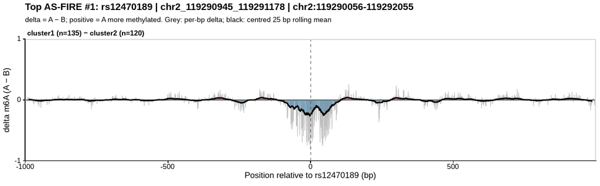

rank01_rs12470189_chr2_119290945_119291178 — pairwise m6A delta

## rank02_rs2236610_chr21_34688259_34688428

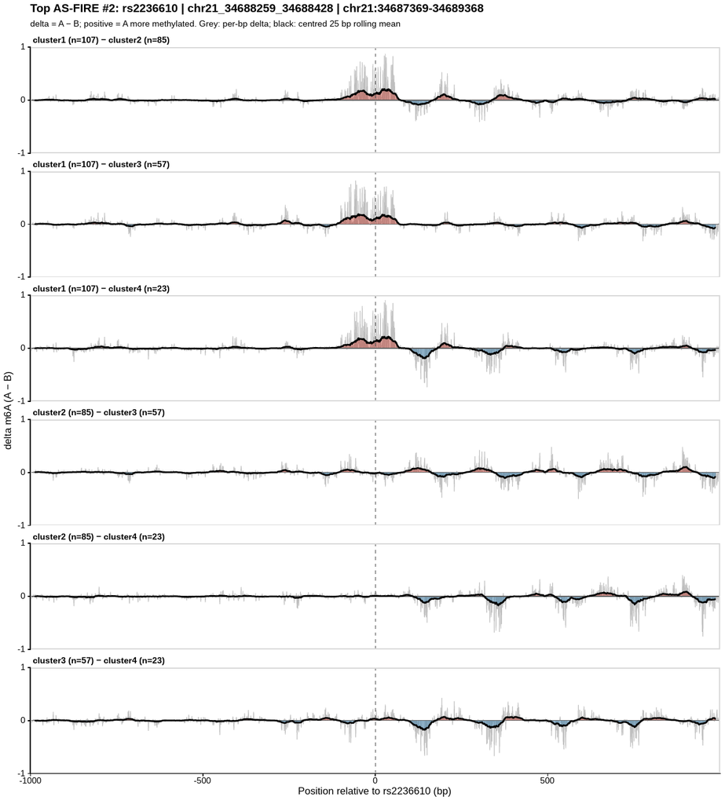

rank02_rs2236610_chr21_34688259_34688428 — pairwise m6A delta

## rank03_rs4061832_chr3_98334086_98334294

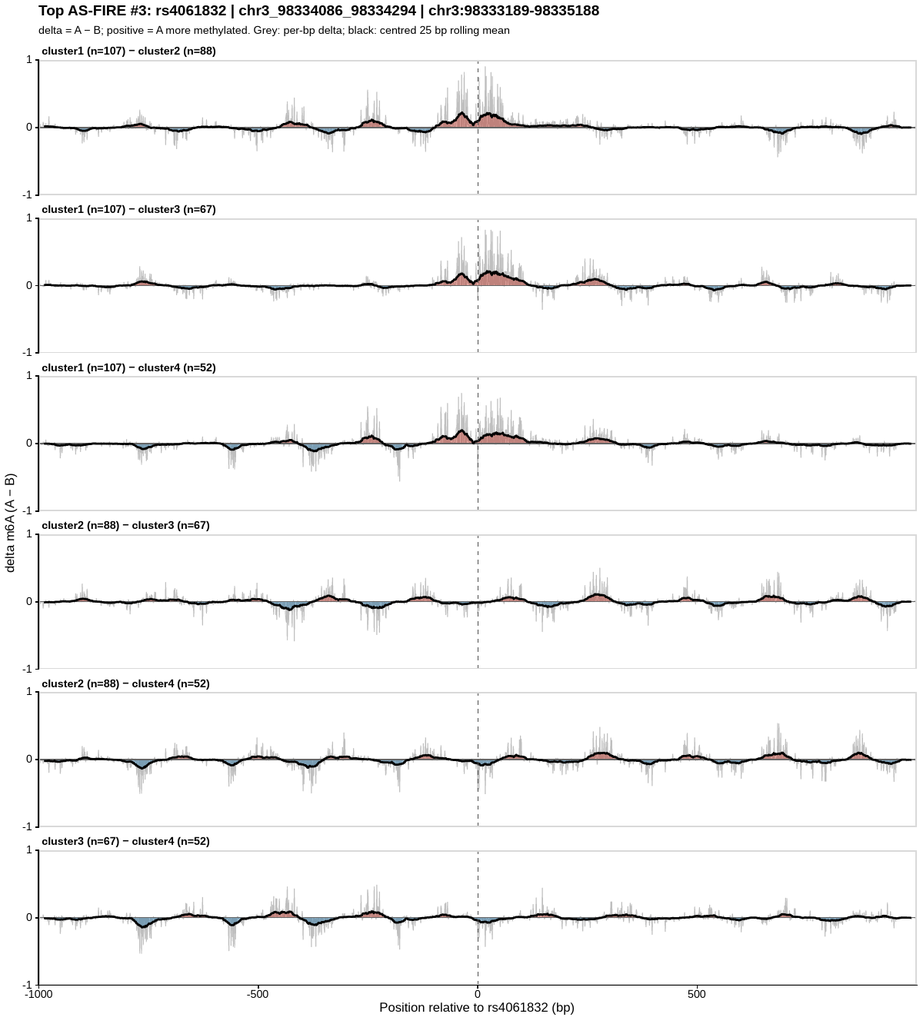

rank03_rs4061832_chr3_98334086_98334294 — pairwise m6A delta

## rank04_rs170738_chr5_55421001_55421578

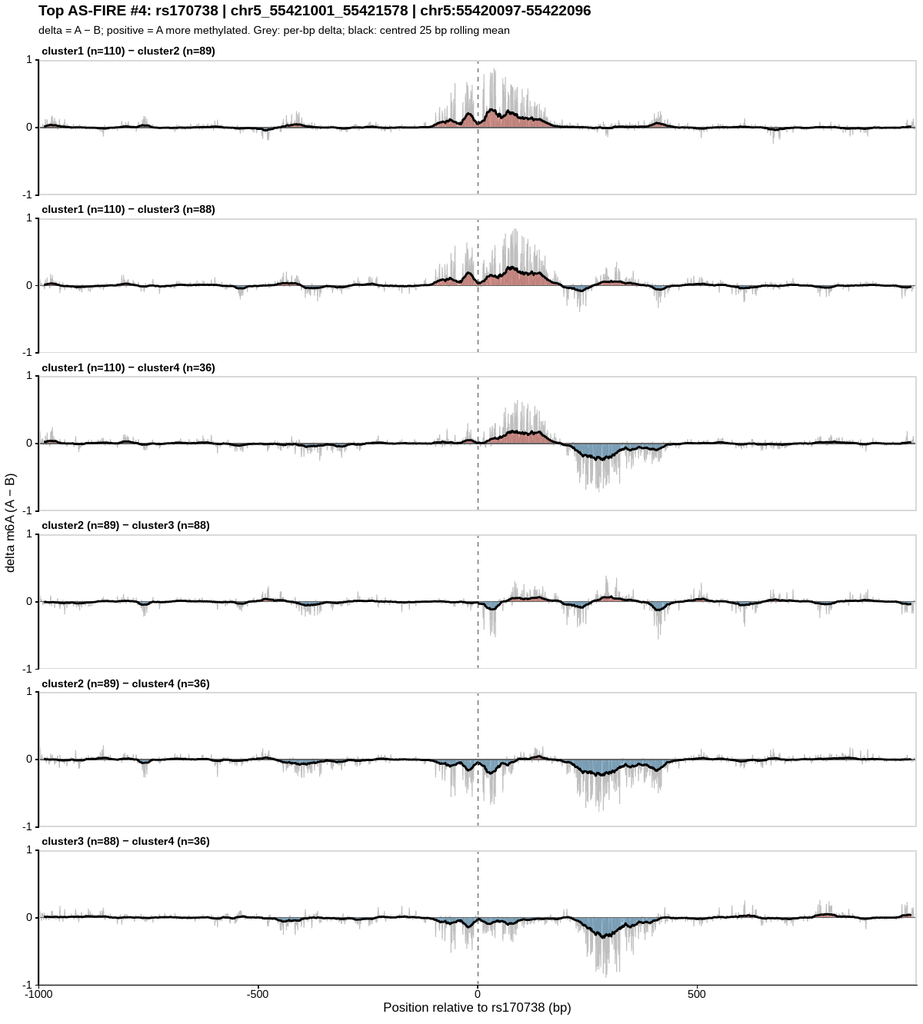

rank04_rs170738_chr5_55421001_55421578 — pairwise m6A delta

## rank05_rs1457288_chr8_109521517_109521780

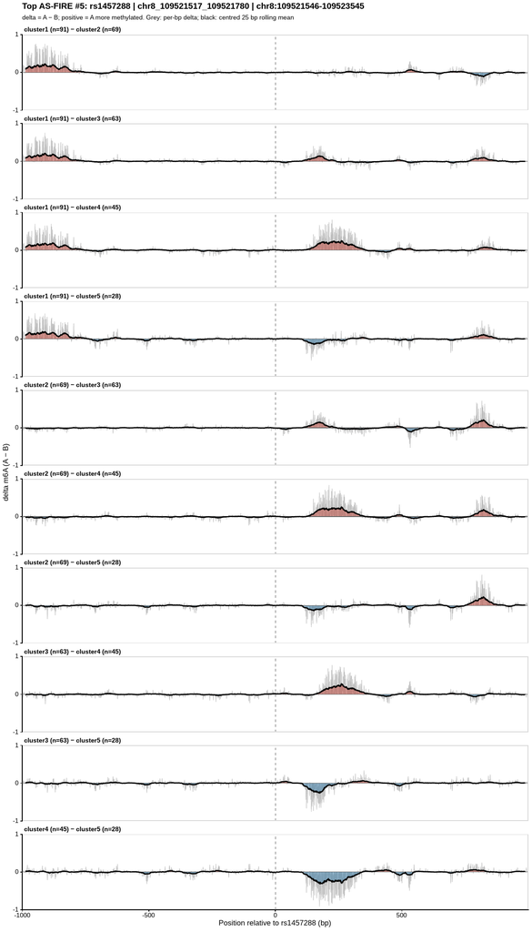

rank05_rs1457288_chr8_109521517_109521780 — pairwise m6A delta